# Introduction

## Table of Contents:

- Data Assessment
- Data Cleaning
- Data Exploration

## Desired Statistics:

- Total Points Won-the total points won by each player divided by the total number of points played. Expressed as a fraction and percentage.
- Winners-a total count for each player of actions that end in w. Ideally broken down by each stroke type. ex forehand winners, backhand winners, etc. as well as the overall total.
- Unforced Errors-a total count for each player of actions that end in ue done the same as winners above.
- Forced Errors-the same as the above winners and unforced errors but for actions that end in fe.
- Average rally length-the total number of actions by each player once a point has started with a serve in play. Ex. if a player hits a first serve and second serve then only the second serve that went in counts as the rally shot. Typically actions that are errors are also not counted but for now I'd like to try it with all shots that occur after a serve has gone in. I'd like this presented with just the average number (ex. 5.2).
- I would like the above in total numbers for the whole match as well as for each set played.

```python
import pandas as pd
import numpy as np
from scipy.interpolate import make_interp_spline
import matplotlib.pyplot as plt
import seaborn as sns

%matplotlib inline
sns.set_theme()
```

```python
df = pd.read_csv('MichaelsVsHarrison.csv')
```

# Data Wrangling

## Data Assessement

```python
df.head()
```

|  | Action | Action number | Best of | Game | Match_id | Player with action | Player1 game score | Player1 match score | Player1 set score | Player2 game score | ... | Player_1 | Player_2 | Point number | Point winner | Receiving | Serve number | Serve velocity | Serving | Set | Tournament name |
| --- | --- | --- | --- | --- | --- | --- | --- | --- | --- | --- | --- | --- | --- | --- | --- | --- | --- | --- | --- | --- | --- |
| 0 | FS | NaN | 3.0 | 1.0 | 0.0 | Michaels | 0 | 0.0 | 0.0 | 0 | ... | Michaels | Harrison | 1.0 | Michaels | Harrison | 1.0 | NaN | Michaels | 1.0 | Regionals |
| 1 | fs | 1.0 | 3.0 | 1.0 | 0.0 | Harrison | 0 | 0.0 | 0.0 | 0 | ... | Michaels | Harrison | 1.0 | Michaels | Harrison | NaN | NaN | Michaels | 1.0 | Regionals |
| 2 | fds | 2.0 | 3.0 | 1.0 | 0.0 | Michaels | 0 | 0.0 | 0.0 | 0 | ... | Michaels | Harrison | 1.0 | Michaels | Harrison | NaN | NaN | Michaels | 1.0 | Regionals |
| 3 | fnfe | 3.0 | 3.0 | 1.0 | 0.0 | Harrison | 0 | 0.0 | 0.0 | 0 | ... | Michaels | Harrison | 1.0 | Michaels | Harrison | NaN | NaN | Michaels | 1.0 | Regionals |
| 4 | FS | NaN | 3.0 | 1.0 | 0.0 | Michaels | 15 | 0.0 | 0.0 | 0 | ... | Michaels | Harrison | 2.0 | Michaels | Harrison | 1.0 | NaN | Michaels | 1.0 | Regionals |

5 rows × 22 columns

Order of columns is jumbled

```python
df.columns
```

```
Index(['Action', 'Action number', 'Best of', 'Game', 'Match_id',
       'Player with action', 'Player1 game score', 'Player1 match score',
       'Player1 set score', 'Player2 game score', 'Player2 match score',
       'Player2 set score', 'Player_1', 'Player_2', 'Point number',
       'Point winner', 'Receiving', 'Serve number', 'Serve velocity',
       'Serving', 'Set', 'Tournament name'],
      dtype='object')
```

Column names are not consistent

```python
df.info()
```

```
<class 'pandas.core.frame.DataFrame'>
RangeIndex: 1243 entries, 0 to 1242
Data columns (total 22 columns):
 #   Column               Non-Null Count  Dtype
---  ------               --------------  -----
 0   Action               1243 non-null   object
 1   Action number        967 non-null    float64
 2   Best of              1243 non-null   float64
 3   Game                 1243 non-null   float64
 4   Match_id             1243 non-null   float64
 5   Player with action   1243 non-null   object
 6   Player1 game score   1243 non-null   object
 7   Player1 match score  1243 non-null   float64
 8   Player1 set score    1243 non-null   float64
 9   Player2 game score   1243 non-null   object
 10  Player2 match score  1243 non-null   float64
 11  Player2 set score    1243 non-null   float64
 12  Player_1             1243 non-null   object
 13  Player_2             1243 non-null   object
 14  Point number         1243 non-null   float64
 15  Point winner         1243 non-null   object
 16  Receiving            1243 non-null   object
 17  Serve number         276 non-null    float64
 18  Serve velocity       0 non-null      float64
 19  Serving              1243 non-null   object
 20  Set                  1243 non-null   float64
 21  Tournament name      1243 non-null   object
dtypes: float64(12), object(10)
memory usage: 165.1+ KB
```

```python
df.isnull().any()
```

```
Action                 False
Action number           True
Best of                False
Game                   False
Match_id               False
Player with action     False
Player1 game score     False
Player1 match score    False
Player1 set score      False
Player2 game score     False
Player2 match score    False
Player2 set score      False
Player_1               False
Player_2               False
Point number           False
Point winner           False
Receiving              False
Serve number            True
Serve velocity          True
Serving                False
Set                    False
Tournament name        False
dtype: bool
```

Serve Velocity column is empty

```python
df.dtypes
```

```
Action                  object
Action number          float64
Best of                float64
Game                   float64
Match_id               float64
Player with action      object
Player1 game score      object
Player1 match score    float64
Player1 set score      float64
Player2 game score      object
Player2 match score    float64
Player2 set score      float64
Player_1                object
Player_2                object
Point number           float64
Point winner            object
Receiving               object
Serve number           float64
Serve velocity         float64
Serving                 object
Set                    float64
Tournament name         object
dtype: object
```

Most of the columns contain wrong data types

```python
df['Player1 game score'].unique()
```

```
array(['0', '15', '30', '40', 'D', 'A', '1', '2', '3', '4', '5', '6'],
      dtype=object)
```

```python
df.describe()
```

|  | Action number | Best of | Game | Match_id | Player1 match score | Player1 set score | Player2 match score | Player2 set score | Point number | Serve number | Serve velocity | Set |
| --- | --- | --- | --- | --- | --- | --- | --- | --- | --- | --- | --- | --- |
| count | 967.000000 | 1243.0 | 1243.000000 | 1243.0 | 1243.000000 | 1243.000000 | 1243.000000 | 1243.000000 | 1243.000000 | 276.000000 | 0.0 | 1243.000000 |
| mean | 5.395036 | 3.0 | 5.720837 | 0.0 | 0.308126 | 2.224457 | 0.773130 | 2.496380 | 4.076428 | 1.329710 | NaN | 2.081255 |
| std | 4.509835 | 0.0 | 3.191440 | 0.0 | 0.461905 | 1.816984 | 0.418977 | 1.589198 | 2.371961 | 0.542708 | NaN | 0.727199 |
| min | 1.000000 | 3.0 | 1.000000 | 0.0 | 0.000000 | 0.000000 | 0.000000 | 0.000000 | 1.000000 | 1.000000 | NaN | 1.000000 |
| 25% | 2.000000 | 3.0 | 3.000000 | 0.0 | 0.000000 | 1.000000 | 1.000000 | 1.000000 | 2.000000 | 1.000000 | NaN | 2.000000 |
| 50% | 4.000000 | 3.0 | 6.000000 | 0.0 | 0.000000 | 2.000000 | 1.000000 | 3.000000 | 4.000000 | 1.000000 | NaN | 2.000000 |
| 75% | 7.000000 | 3.0 | 8.000000 | 0.0 | 1.000000 | 3.500000 | 1.000000 | 3.000000 | 6.000000 | 2.000000 | NaN | 3.000000 |
| max | 26.000000 | 3.0 | 13.000000 | 0.0 | 1.000000 | 6.000000 | 1.000000 | 6.000000 | 12.000000 | 4.000000 | NaN | 3.000000 |

Best of column and Match_id are not useful because there is only one match in this dataframe

```python
df['Tournament name'].unique()
```

```
array(['Regionals'], dtype=object)
```

Tournament name column is not useful

### Data Quality Problems:

1. Serve Velocity column is empty
2. Best of and Match_id columns are not useful because there is only one match in this dataframe
3. Tournament name column is not useful
4. Most of the columns contain wrong data types

### Data Tideness Problems:

1. Column names are not consistent
2. Order of columns is jumbeled

## Data Cleaning

### Data Quality

1. Serve Velocity column is empty → Drop Serve Velocity column
2. Best of and Match_id columns are not useful because there is only one match in this dataframe → Drop Match_id and Best of columns
3. Tournament name column is not useful → Drop Tournament name column

```python
df.drop(['Match_id', 'Best of', 'Serve velocity', 'Tournament name'], axis=1, inplace=True)
df.columns
```

```
Index(['Action', 'Action number', 'Game', 'Player with action',
       'Player1 game score', 'Player1 match score', 'Player1 set score',
       'Player2 game score', 'Player2 match score', 'Player2 set score',
       'Player_1', 'Player_2', 'Point number', 'Point winner', 'Receiving',
       'Serve number', 'Serving', 'Set'],
      dtype='object')
```

1. Most of the columns contain wrong data types → Fix Data Types

```python
df.dtypes
```

```
Action                  object
Action number          float64
Game                   float64
Player with action      object
Player1 game score      object
Player1 match score    float64
Player1 set score      float64
Player2 game score      object
Player2 match score    float64
Player2 set score      float64
Player_1                object
Player_2                object
Point number           float64
Point winner            object
Receiving               object
Serve number           float64
Serving                 object
Set                    float64
dtype: object
```

```python
dtypes = df.dtypes
columns = dtypes[dtypes.values == 'float64'].index
df[columns] = df[columns].astype('Int64')
df.dtypes
```

```
Action                 object
Action number           Int64
Game                    Int64
Player with action     object
Player1 game score     object
Player1 match score     Int64
Player1 set score       Int64
Player2 game score     object
Player2 match score     Int64
Player2 set score       Int64
Player_1               object
Player_2               object
Point number            Int64
Point winner           object
Receiving              object
Serve number            Int64
Serving                object
Set                     Int64
dtype: object
```

### Data Tideness

1. Column names are not consistent → Replace all whitespaces with underscore and make all column names lowercase

```python
df.rename(columns=lambda x: x.lower().replace(' ', '_'), inplace=True)
df.columns
```

```
Index(['action', 'action_number', 'game', 'player_with_action',
       'player1_game_score', 'player1_match_score', 'player1_set_score',
       'player2_game_score', 'player2_match_score', 'player2_set_score',
       'player_1', 'player_2', 'point_number', 'point_winner', 'receiving',
       'serve_number', 'serving', 'set'],
      dtype='object')
```

```python
new_order = ['player1_match_score', 'player2_match_score', 'set', 'player1_set_score', 'player2_set_score', 'game', 'player1_game_score', 'player2_game_score', 'point_number', 'serving', 'serve_number', 'receiving', 'player_with_action', 'action', 'action_number', 'point_winner']
df = df[new_order]
df.head()
```

|  | player1_match_score | player2_match_score | set | player1_set_score | player2_set_score | game | player1_game_score | player2_game_score | point_number | serving | serve_number | receiving | player_with_action | action | action_number | point_winner |
| --- | --- | --- | --- | --- | --- | --- | --- | --- | --- | --- | --- | --- | --- | --- | --- | --- |
| 0 | 0 | 0 | 1 | 0 | 0 | 1 | 0 | 0 | 1 | Michaels | 1 | Harrison | Michaels | FS | <NA> | Michaels |
| 1 | 0 | 0 | 1 | 0 | 0 | 1 | 0 | 0 | 1 | Michaels | <NA> | Harrison | Harrison | fs | 1 | Michaels |
| 2 | 0 | 0 | 1 | 0 | 0 | 1 | 0 | 0 | 1 | Michaels | <NA> | Harrison | Michaels | fds | 2 | Michaels |
| 3 | 0 | 0 | 1 | 0 | 0 | 1 | 0 | 0 | 1 | Michaels | <NA> | Harrison | Harrison | fnfe | 3 | Michaels |
| 4 | 0 | 0 | 1 | 0 | 0 | 1 | 15 | 0 | 2 | Michaels | 1 | Harrison | Michaels | FS | <NA> | Michaels |

# Data Exploration

## Total Points Won

*the total points won by each player divided by the total number of points played. Expressed as a fraction and percentage.*

### Total Points Won

```python
points = df.groupby(['set', 'game', 'point_number'])['point_winner'].unique()
total_points = len(points.values)
total_won_points = [x[0] for x in points.values]
Michaels_won_points = total_won_points.count('Michaels')
Harrison_won_points = total_won_points.count('Harrison')
Michaels_win_fraction = Michaels_won_points / total_points
Harrison_win_fraction = Harrison_won_points / total_points
```

|  | Fraction of points won | Percentage of points won |
| --- | --- | --- |
| Michaels | 99/194 | 51.030928 |
| Harrison | 95/194 | 48.969072 |

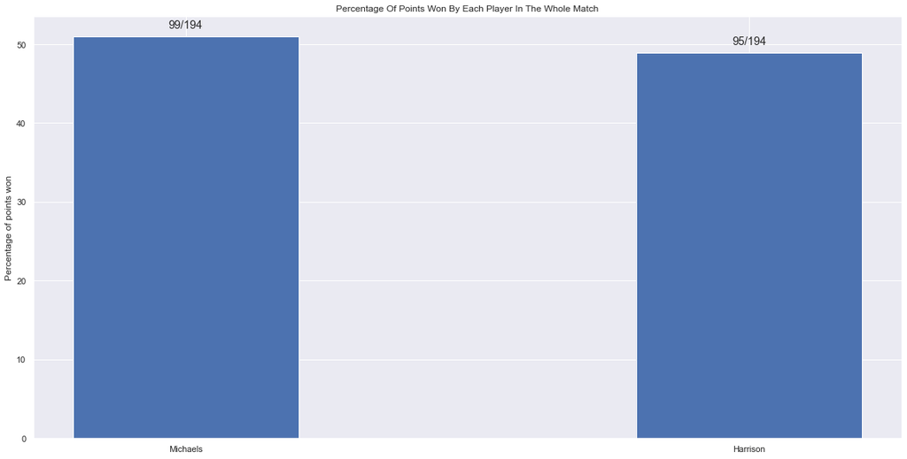

```python
points_won = pd.DataFrame({'Fraction of points won': [str(Michaels_won_points)+'/'+str(total_points), str(Harrison_won_points)+'/'+str(total_points)],
              'Percentage of points won':[Michaels_win_fraction*100, Harrison_win_fraction*100]}, index=['Michaels', 'Harrison'])

plt.figure(figsize=(20,10))
plt.bar(np.arange(2), points_won['Percentage of points won'], 0.4, tick_label=['Michaels','Harrison'])
plt.text(0, points_won['Percentage of points won'][0]+1, points_won['Fraction of points won'][0], ha='center', fontsize='large')
plt.text(1, points_won['Percentage of points won'][1]+1, points_won['Fraction of points won'][1], ha='center', fontsize='large')
plt.ylabel('Percentage of points won')
plt.title('Percentage of points won by each player in the whole match'.title());

points_won
```

### Total Points Won per set

```python
# Create a dataframe for each set
df_1 = df[df['set'] == 1].drop('set', axis=1)
df_2 = df[df['set'] == 2].drop('set', axis=1)
df_3 = df[df['set'] == 3].drop('set', axis=1)
```

```python
points_percentage = {}
for df_set, set_num in [(df_1, 'Set 1'),(df_2, 'Set 2'),(df_3, 'Set 3')]:
    points = df_set.groupby(['game', 'point_number'])['point_winner'].unique()
    total_points = len(points.values)
    total_won_points = [x[0] for x in points.values]
    Michaels_won_points = total_won_points.count('Michaels')
    Harrison_won_points = total_won_points.count('Harrison')
    Michaels_win_fraction = Michaels_won_points / total_points
    Harrison_win_fraction = Harrison_won_points / total_points
    Michaels_fraction = str(Michaels_won_points)+'/'+str(total_points)
    Harrison_fraction = str(Harrison_won_points)+'/'+str(total_points)
    points_percentage[set_num] = [Michaels_fraction, Michaels_win_fraction*100, Harrison_fraction, Harrison_win_fraction*100]

df_points_won_per_set = pd.DataFrame(points_percentage,
                                     index=pd.MultiIndex.from_tuples([('Michaels', 'Fraction'), ('Michaels', 'Percentage'), ('Harrison', 'Fraction'), ('Harrison', 'Percentage')],
                                     names=['Player','Form']))
Average = df_points_won_per_set[df_points_won_per_set.index.get_level_values('Form').isin(['Percentage'])].mean(axis=1)
df_points_won_per_set = df_points_won_per_set.merge(Average.rename('Average'), how='outer', left_index=True, right_index=True)
```

| Player | Form | Set 1 | Set 2 | Set 3 | Average |
| --- | --- | --- | --- | --- | --- |
| Harrison | Fraction | 27/46 | 42/86 | 26/62 | NaN |
|  | Percentage | 58.695652 | 48.837209 | 41.935484 | 49.822782 |
| Michaels | Fraction | 19/46 | 44/86 | 36/62 | NaN |
|  | Percentage | 41.304348 | 51.162791 | 58.064516 | 50.177218 |

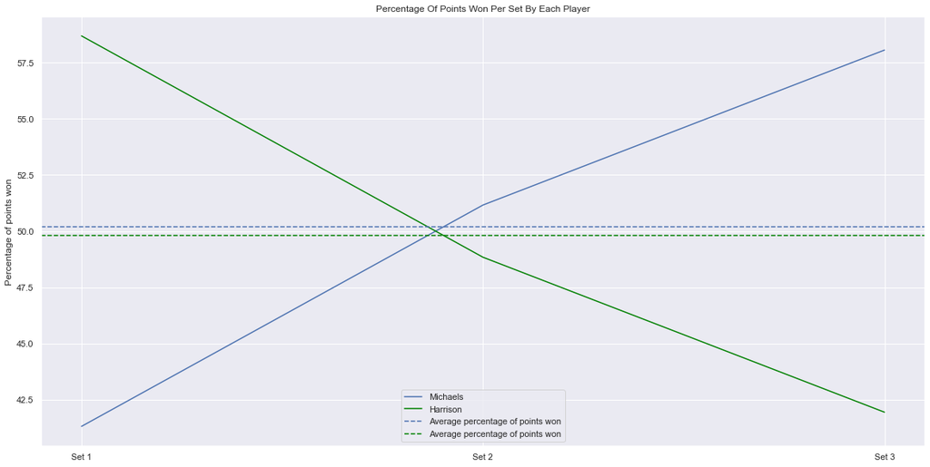

```python
plt.figure(figsize=(20,10))
plt.plot(df_points_won_per_set.loc['Michaels'].loc['Percentage'][:3], label='Michaels',)
plt.plot(df_points_won_per_set.loc['Harrison'].loc['Percentage'][:3], label='Harrison', color='green')
plt.axhline(df_points_won_per_set.loc['Michaels'].loc['Percentage'][-1], linestyle='--', label='Average percentage of points won')
plt.axhline(df_points_won_per_set.loc['Harrison'].loc['Percentage'][-1], linestyle='--', label='Average percentage of points won', color='green')
plt.ylabel('Percentage of points won')
plt.title('Percentage of points won per set by each player'.title())
plt.legend();

df_points_won_per_set
```

## Winners

*A total count for each player of actions that end in w. Ideally broken down by each stroke type. ex forehand winners, backhand winners, etc. as well as the overall total.*

### Total Winners

```python
def total_shots(shot):
    """
    Count the number of shots that ended the point made by each player in the whole match

    Args:
        shot (str): type of point ender ('fe', 'ue', 'w', etc.)

    Returns:
        Pandas Dataframe of number of shots that ended the point made by each player in the match
    """
    shots = df[df.action.str.contains(shot)].groupby('player_with_action')['action'].value_counts()
    Michaels_shots = pd.DataFrame(shots['Michaels']).rename(columns={'action':'Michaels'})
    Harrison_shots = pd.DataFrame(shots['Harrison']).rename(columns={'action':'Harrison'})
    df_shots = pd.merge(Michaels_shots, Harrison_shots, how='outer', left_index=True, right_index=True).fillna(0).astype('int64')
    df_shots.loc['Total Forehand'] = [df_shots[df_shots.index.get_level_values('action').str.startswith('f')]['Michaels'].sum(), df_shots[df_shots.index.get_level_values('action').str.startswith('f')]['Harrison'].sum()]
    df_shots.loc['Total Backhand'] = [df_shots[df_shots.index.get_level_values('action').str.startswith('b')]['Michaels'].sum(), df_shots[df_shots.index.get_level_values('action').str.startswith('b')]['Harrison'].sum()]
    df_shots = df_shots.append(df_shots[:-2].sum().rename('Total'))
    return df_shots
```

| action | Michaels | Harrison |
| --- | --- | --- |
| bdsw | 1 | 0 |
| bdvw | 2 | 1 |
| bow | 0 | 1 |
| bvw | 2 | 0 |
| bw | 3 | 8 |
| fdsw | 1 | 3 |
| folw | 1 | 1 |
| fsvw | 0 | 1 |
| fvw | 1 | 1 |
| fw | 14 | 9 |
| ow | 2 | 1 |
| Total Forehand | 17 | 15 |
| Total Backhand | 8 | 10 |
| Total | 27 | 26 |

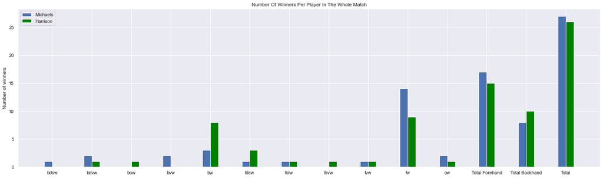

```python
df_winners = total_shots('w')

plt.figure(figsize=(25,7))
plt.bar(np.arange(len(df_winners['Michaels']))-0.2, df_winners['Michaels'], 0.2, align='edge', tick_label=df_winners.index, label='Michaels')
plt.bar(np.arange(len(df_winners['Harrison'])), df_winners['Harrison'], 0.2, align='edge', tick_label=df_winners.index, label='Harrison', color='green')
plt.ylabel('Number of winners')
plt.title('Number of winners per player in the whole match'.title())
plt.legend();

df_winners
```

### Winners Per Set

```python
def shots_per_set(shot):  # sourcery skip: list-comprehension
    """
    Count the number of shots that ended the point made by each player in each set and in the whole match

    Args:
        shot (str): type of point ender ('fe', 'ue', 'w', etc.)

    Returns:
        Pandas Dataframe of number of shots that ended the point made by each player in each set and the match
    """
    shots_per_set = df[df.action.str.contains(shot)].groupby(['set', 'player_with_action'])['action'].value_counts()
    df_shots_per_set = pd.DataFrame({'set 1':shots_per_set[1], 'set 2':shots_per_set[2], 'set 3':shots_per_set[3]}).fillna(0).astype('int64')
    players = []
    for player in ['Michaels','Harrison']:
        players.append(df_shots_per_set.loc[player].append([pd.Series(df_shots_per_set.loc[player][df_shots_per_set.loc[player].index.get_level_values('action').str.startswith('f')].sum().values, index=df_shots_per_set.columns, name='Total Forehand'),
                                                            pd.Series(df_shots_per_set.loc[player][df_shots_per_set.loc[player].index.get_level_values('action').str.startswith('b')].sum().values, index=df_shots_per_set.columns, name='Total Backhand'),
                                                            pd.Series(df_shots_per_set.loc[player].sum(), name='All Shots')]))
    df_shots_per_set = pd.concat(players, keys=['Michaels','Harrison'], names=['Player','action'])
    df_shots_per_set = df_shots_per_set.merge(df_shots_per_set.sum(axis=1).rename('Total'), how='outer', left_index=True, right_index=True)
    return df_shots_per_set
```

```python
def plot_shots(df, shot):
    '''Plot a stacked bar chart of dataframe of shots'''
    for a in df.index.get_level_values('action'):
        total_per_player = df[a == df.index.get_level_values('action')]
        if total_per_player.shape[0] == 1:
            for player in ['Michaels','Harrison']:
                if a not in df.loc[player].index.get_level_values('action'):
                    df = df.append(pd.Series(np.full(4,0,'int64'), name=(player, a), index=df.columns))
    shot_sum = []
    for a in df.index.get_level_values('action'):
        total_per_player = df[a == df.index.get_level_values('action')]
        shot_sum.append(total_per_player['Total'].sum())

    df = df.merge(pd.Series(shot_sum, name='Total for both palyers', index=df.index), how='outer', left_index=True, right_index=True)
    code = [list(df.index.get_level_values('action').unique()).index(a) for a in df.index.get_level_values('action')]
    df = df.merge(pd.Series(code, index=df.index, name='Code'), how='outer', left_index=True, right_index=True)
    harrison_winners = df.loc['Harrison'].sort_values(by=['Total for both palyers','Code'], axis=0)
    michaels_winners = df.loc['Michaels'].sort_values(by=['Total for both palyers','Code'], axis=0)

    plt.figure(figsize=(25,10))
    p4 = plt.bar(np.arange(len(michaels_winners['set 1']))-0.2, michaels_winners['set 1'], 0.2, align='edge', tick_label=michaels_winners.index, label='Set 1')
    p5 = plt.bar(np.arange(len(michaels_winners['set 2']))-0.2, michaels_winners['set 2'], 0.2, p4.datavalues, align='edge', tick_label=michaels_winners.index, label='Set 2')
    p6 = plt.bar(np.arange(len(michaels_winners['set 3']))-0.2, michaels_winners['set 3'], 0.2, p5.datavalues+p4.datavalues,align='edge', tick_label=michaels_winners.index, label='Set 3')

    p4_labels = pd.Series(p4.datavalues).replace(0,'')
    p5_labels = pd.Series(p5.datavalues).replace(0,'')
    p6_labels = pd.Series(p6.datavalues).replace(0,'')

    plt.bar_label(p4, p4_labels, label_type='center')
    plt.bar_label(p5, p5_labels, label_type='center')
    plt.bar_label(p6, p6_labels, label_type='center')
    plt.bar_label(p6)

    p1 = plt.bar(np.arange(len(harrison_winners['set 1'])), harrison_winners['set 1'], 0.2, align='edge', tick_label=harrison_winners.index, color=p4.patches[0].get_facecolor())
    p2 = plt.bar(np.arange(len(harrison_winners['set 2'])), harrison_winners['set 2'], 0.2, p1.datavalues, align='edge', tick_label=harrison_winners.index, color=p5.patches[0].get_facecolor())
    p3 = plt.bar(np.arange(len(harrison_winners['set 3'])), harrison_winners['set 3'], 0.2, p2.datavalues+p1.datavalues, align='edge', tick_label=harrison_winners.index, color=p6.patches[0].get_facecolor())

    p1_labels = pd.Series(p1.datavalues).replace(0,'')
    p2_labels = pd.Series(p2.datavalues).replace(0,'')
    p3_labels = pd.Series(p3.datavalues).replace(0,'')

    plt.bar_label(p1, p1_labels, label_type='center')
    plt.bar_label(p2, p2_labels, label_type='center')
    plt.bar_label(p3, p3_labels, label_type='center')
    plt.bar_label(p3)

    plt.ylabel('Number of '+shot)
    plt.title("Number of "+shot+" per set for each shot".title())
    plt.legend();
```

| Player | action | set 1 | set 2 | set 3 | Total |
| --- | --- | --- | --- | --- | --- |
| Michaels | bdsw | 0 | 1 | 0 | 1 |
|  | bdvw | 0 | 1 | 1 | 2 |
|  | bvw | 0 | 0 | 2 | 2 |
|  | bw | 1 | 0 | 2 | 3 |
|  | fdsw | 1 | 0 | 0 | 1 |
|  | folw | 0 | 1 | 0 | 1 |
|  | fvw | 0 | 1 | 0 | 1 |
|  | fw | 3 | 7 | 4 | 14 |
|  | ow | 0 | 2 | 0 | 2 |
|  | Total Forehand | 4 | 9 | 4 | 17 |
|  | Total Backhand | 1 | 2 | 5 | 8 |
|  | All Shots | 5 | 13 | 9 | 27 |
| Harrison | bdvw | 0 | 1 | 0 | 1 |
|  | bow | 0 | 1 | 0 | 1 |
|  | bw | 3 | 2 | 3 | 8 |
|  | fdsw | 2 | 1 | 0 | 3 |
|  | folw | 1 | 0 | 0 | 1 |
|  | fsvw | 0 | 1 | 0 | 1 |
|  | fvw | 0 | 0 | 1 | 1 |
|  | fw | 3 | 2 | 4 | 9 |
|  | ow | 0 | 1 | 0 | 1 |
|  | Total Forehand | 6 | 4 | 5 | 15 |
|  | Total Backhand | 3 | 4 | 3 | 10 |
|  | All Shots | 9 | 9 | 8 | 26 |

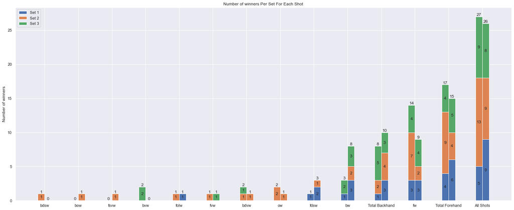

```python
df_winners_per_set = shots_per_set('w')
plot_shots(df_winners_per_set, 'winners')
df_winners_per_set
```

## Unforced Errors

*a total count for each player of actions that end in ue done the same as winners above.*

### Total unforced errors

| action | Michaels | Harrison |
| --- | --- | --- |
| bdsnue | 1 | 0 |
| bdsue | 1 | 0 |
| bnue | 8 | 7 |
| bsnue | 1 | 1 |
| bsue | 0 | 2 |
| bue | 4 | 9 |
| fdsnue | 1 | 1 |
| fdsue | 0 | 1 |
| fnue | 6 | 1 |
| fsvue | 1 | 1 |
| fue | 9 | 7 |
| Total Forehand | 17 | 11 |
| Total Backhand | 15 | 19 |
| Total | 32 | 30 |

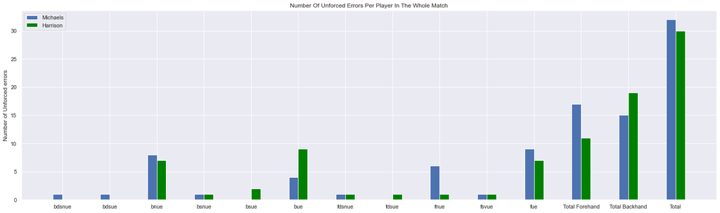

```python
df_ue = total_shots('ue')

plt.figure(figsize=(25,7))
plt.bar(np.arange(len(df_ue['Michaels']))-0.2, df_ue['Michaels'], 0.2, align='edge', tick_label=df_ue.index, label='Michaels')
plt.bar(np.arange(len(df_ue['Harrison'])), df_ue['Harrison'], 0.2, align='edge', tick_label=df_ue.index, label='Harrison', color='green')
plt.ylabel('Number of Unforced errors')
plt.title('Number of unforced errors per player in the whole match'.title())
plt.legend();

df_ue
```

### Unforced Errors per set

| Player | action | set 1 | set 2 | set 3 | Total |
| --- | --- | --- | --- | --- | --- |
| Michaels | bdsnue | 0 | 1 | 0 | 1 |
|  | bdsue | 0 | 0 | 1 | 1 |
|  | bnue | 6 | 2 | 0 | 8 |
|  | bsnue | 0 | 1 | 0 | 1 |
|  | bue | 1 | 2 | 1 | 4 |
|  | fdsnue | 0 | 1 | 0 | 1 |
|  | fnue | 1 | 3 | 2 | 6 |
|  | fsvue | 0 | 0 | 1 | 1 |
|  | fue | 3 | 2 | 4 | 9 |
|  | Total Forehand | 4 | 6 | 7 | 17 |
|  | Total Backhand | 7 | 6 | 2 | 15 |
|  | All Shots | 11 | 12 | 9 | 32 |
| Harrison | bnue | 2 | 1 | 4 | 7 |
|  | bsnue | 0 | 1 | 0 | 1 |
|  | bsue | 1 | 0 | 1 | 2 |
|  | bue | 1 | 5 | 3 | 9 |
|  | fdsnue | 1 | 0 | 0 | 1 |
|  | fdsue | 0 | 0 | 1 | 1 |
|  | fnue | 0 | 1 | 0 | 1 |
|  | fsvue | 1 | 0 | 0 | 1 |
|  | fue | 3 | 2 | 2 | 7 |
|  | Total Forehand | 5 | 3 | 3 | 11 |
|  | Total Backhand | 4 | 7 | 8 | 19 |
|  | All Shots | 9 | 10 | 11 | 30 |

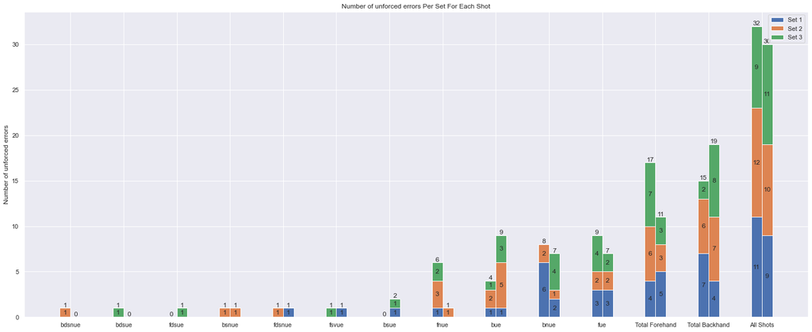

```python
df_unforced_errors_per_set = shots_per_set('ue')
plot_shots(df_unforced_errors_per_set, 'unforced errors')
df_unforced_errors_per_set
```

## Forced Errors

*the same as the above winners and unforced errors but for actions that end in fe.*

### Total forced errors

| action | Michaels | Harrison |
| --- | --- | --- |
| bdlfe | 2 | 0 |
| bfe | 2 | 1 |
| bnfe | 0 | 1 |
| bolfe | 1 | 2 |
| bsfe | 0 | 1 |
| bvfe | 0 | 2 |
| fdlfe | 1 | 0 |
| ffe | 1 | 1 |
| fnfe | 3 | 2 |
| fsfe | 1 | 3 |
| fsnfe | 0 | 1 |
| fvnfe | 1 | 0 |
| fxfe | 1 | 1 |
| Total Forehand | 8 | 8 |
| Total Backhand | 5 | 7 |
| Total | 13 | 15 |

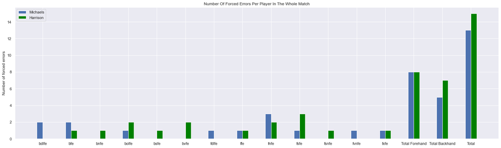

```python
df_fe = total_shots('fe')

plt.figure(figsize=(25,7))
plt.bar(np.arange(len(df_fe['Michaels']))-0.2, df_fe['Michaels'], 0.2, align='edge', tick_label=df_fe.index, label='Michaels')
plt.bar(np.arange(len(df_fe['Harrison'])), df_fe['Harrison'], 0.2, align='edge', tick_label=df_fe.index, label='Harrison', color='green')
plt.ylabel('Number of forced errors')
plt.title('Number of forced errors per player in the whole match'.title())
plt.legend();

df_fe
```

### Forced Errors per set

| Player | action | set 1 | set 2 | set 3 | Total |
| --- | --- | --- | --- | --- | --- |
| Michaels | bdlfe | 0 | 2 | 0 | 2 |
|  | bfe | 0 | 1 | 1 | 2 |
|  | bolfe | 0 | 1 | 0 | 1 |
|  | fdlfe | 0 | 0 | 1 | 1 |
|  | ffe | 0 | 1 | 0 | 1 |
|  | fnfe | 0 | 2 | 1 | 3 |
|  | fsfe | 0 | 1 | 0 | 1 |
|  | fvnfe | 0 | 1 | 0 | 1 |
|  | fxfe | 1 | 0 | 0 | 1 |
|  | Total Forehand | 1 | 5 | 2 | 8 |
|  | Total Backhand | 0 | 4 | 1 | 5 |
|  | All Shots | 1 | 9 | 3 | 13 |
| Harrison | bfe | 0 | 0 | 1 | 1 |
|  | bnfe | 0 | 1 | 0 | 1 |
|  | bolfe | 0 | 0 | 2 | 2 |
|  | bsfe | 0 | 0 | 1 | 1 |
|  | bvfe | 0 | 1 | 1 | 2 |
|  | ffe | 0 | 0 | 1 | 1 |
|  | fnfe | 1 | 1 | 0 | 2 |
|  | fsfe | 0 | 2 | 1 | 3 |
|  | fsnfe | 0 | 1 | 0 | 1 |
|  | fxfe | 0 | 1 | 0 | 1 |
|  | Total Forehand | 1 | 5 | 2 | 8 |
|  | Total Backhand | 0 | 2 | 5 | 7 |
|  | All Shots | 1 | 7 | 7 | 15 |

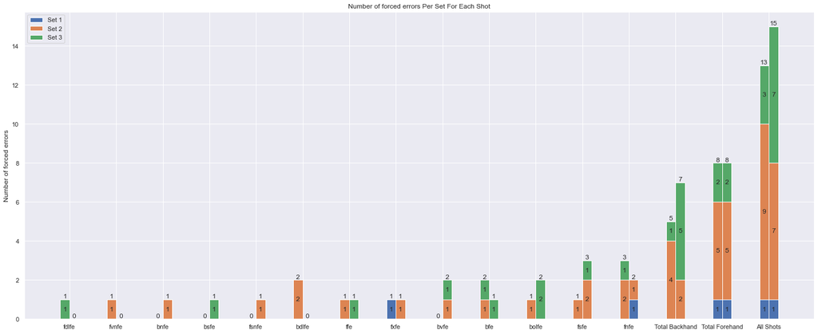

```python
df_forced_errors_per_set = shots_per_set('fe')
plot_shots(df_forced_errors_per_set, 'forced errors')
df_forced_errors_per_set
```

## Net errors

### Total Net Errors

| action | Michaels | Harrison |
| --- | --- | --- |
| bdsnue | 1 | 0 |
| bnfe | 0 | 1 |
| bnr | 2 | 1 |
| bnue | 8 | 7 |
| bsnr | 2 | 0 |
| bsnue | 1 | 1 |
| fdsnue | 1 | 1 |
| fnfe | 3 | 2 |
| fnr | 0 | 1 |
| fnue | 6 | 1 |
| fsnfe | 0 | 1 |
| fsnr | 0 | 1 |
| fvnfe | 1 | 0 |
| Total Forehand | 11 | 7 |
| Total Backhand | 14 | 10 |
| Total | 25 | 17 |

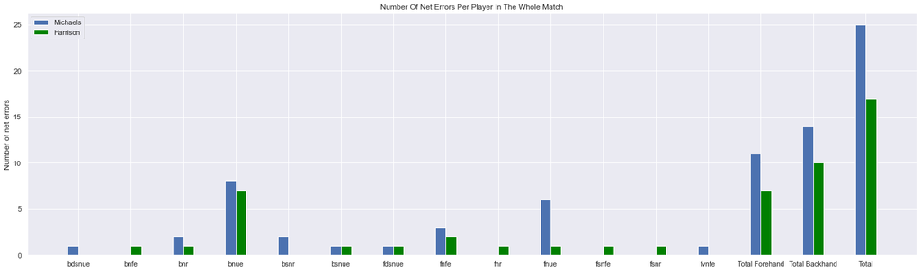

```python
df_net_errors = total_shots('n')

plt.figure(figsize=(25,7))
plt.bar(np.arange(len(df_net_errors['Michaels']))-0.2, df_net_errors['Michaels'], 0.2, align='edge', tick_label=df_net_errors.index, label='Michaels')
plt.bar(np.arange(len(df_net_errors['Harrison'])), df_net_errors['Harrison'], 0.2, align='edge', tick_label=df_net_errors.index, label='Harrison', color='green')
plt.ylabel('Number of net errors')
plt.title('Number of net errors per player in the whole match'.title())
plt.legend();

df_net_errors
```

### Net Errors per set

| Player | action | set 1 | set 2 | set 3 | Total |
| --- | --- | --- | --- | --- | --- |
| Michaels | bdsnue | 0 | 1 | 0 | 1 |
|  | bnr | 0 | 2 | 0 | 2 |
|  | bnue | 6 | 2 | 0 | 8 |
|  | bsnr | 0 | 0 | 2 | 2 |
|  | bsnue | 0 | 1 | 0 | 1 |
|  | fdsnue | 0 | 1 | 0 | 1 |
|  | fnfe | 0 | 2 | 1 | 3 |
|  | fnue | 1 | 3 | 2 | 6 |
|  | fvnfe | 0 | 1 | 0 | 1 |
|  | Total Forehand | 1 | 7 | 3 | 11 |
|  | Total Backhand | 6 | 6 | 2 | 14 |
|  | All Shots | 7 | 13 | 5 | 25 |
| Harrison | bnfe | 0 | 1 | 0 | 1 |
|  | bnr | 0 | 1 | 0 | 1 |
|  | bnue | 2 | 1 | 4 | 7 |
|  | bsnue | 0 | 1 | 0 | 1 |
|  | fdsnue | 1 | 0 | 0 | 1 |
|  | fnfe | 1 | 1 | 0 | 2 |
|  | fnr | 0 | 1 | 0 | 1 |
|  | fnue | 0 | 1 | 0 | 1 |
|  | fsnfe | 0 | 1 | 0 | 1 |
|  | fsnr | 0 | 1 | 0 | 1 |
|  | Total Forehand | 2 | 5 | 0 | 7 |
|  | Total Backhand | 2 | 4 | 4 | 10 |
|  | All Shots | 4 | 9 | 4 | 17 |

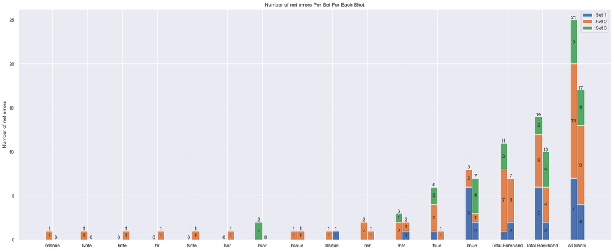

```python
df_net_errors_per_set = shots_per_set('n')
plot_shots(df_net_errors_per_set, 'net errors')
df_net_errors_per_set
```

## A count of baseline forehands by each player

*Count of shots that contain f excluding net shots (shots with a v or o). listed as total forehands/forehands + backhands as well as %.*

```python
def baseline_shots_per_set(shot):
    """
    Count the number of shots that ended the point made by each player in each set and in the whole match

    Args:
        shot (str): type of point ender ('fe', 'ue', 'w', etc.)

    Returns:
        Pandas Dataframe of number of shots that ended the point made by each player in each set and the match
    """
    shots_per_set = df[df.action.str.startswith(shot)].groupby(['set', 'player_with_action'])['action'].value_counts()
    df_shots_per_set = pd.DataFrame({'set 1':shots_per_set[1], 'set 2':shots_per_set[2], 'set 3':shots_per_set[3]}).fillna(0).astype('int64')
    df_shots_per_set = df_shots_per_set[np.logical_not((df_shots_per_set.index.get_level_values('action').str.contains('v'))+(df_shots_per_set.index.get_level_values('action').str.contains('o')))]
    players = [
        df_shots_per_set.loc[player].append(
            [pd.Series(df_shots_per_set.loc[player].sum(), name='All Shots')]
        )
        for player in ['Michaels', 'Harrison']
    ]

    df_shots_per_set = pd.concat(players, keys=['Michaels','Harrison'], names=['Player','action'])
    df_shots_per_set = df_shots_per_set.merge(df_shots_per_set.sum(axis=1).rename('Total'), how='outer', left_index=True, right_index=True)
    return df_shots_per_set
```

| Player | action | set 1 | set 2 | set 3 | Total |
| --- | --- | --- | --- | --- | --- |
| Michaels | f | 39 | 96 | 60 | 195 |
|  | fdl | 1 | 2 | 0 | 3 |
|  | fdlfe | 0 | 0 | 1 | 1 |
|  | fds | 1 | 0 | 2 | 3 |
|  | fdsnue | 0 | 1 | 0 | 1 |
|  | fdsw | 1 | 0 | 0 | 1 |
|  | ffe | 0 | 1 | 0 | 1 |
|  | fnfe | 0 | 2 | 1 | 3 |
|  | fnue | 1 | 3 | 2 | 6 |
|  | fr | 0 | 3 | 0 | 3 |
|  | fs | 2 | 1 | 2 | 5 |
|  | fsfe | 0 | 1 | 0 | 1 |
|  | fue | 3 | 2 | 4 | 9 |
|  | fw | 3 | 7 | 4 | 14 |
|  | fxfe | 1 | 0 | 0 | 1 |
|  | All Shots | 52 | 119 | 76 | 247 |
| Harrison | f | 38 | 78 | 40 | 156 |
|  | fds | 1 | 2 | 4 | 7 |
|  | fdsnue | 1 | 0 | 0 | 1 |
|  | fdsue | 0 | 0 | 1 | 1 |
|  | fdsw | 2 | 1 | 0 | 3 |
|  | ffe | 0 | 0 | 1 | 1 |
|  | fnfe | 1 | 1 | 0 | 2 |
|  | fnr | 0 | 1 | 0 | 1 |
|  | fnue | 0 | 1 | 0 | 1 |
|  | fr | 1 | 2 | 2 | 5 |
|  | fs | 1 | 9 | 8 | 18 |
|  | fsfe | 0 | 2 | 1 | 3 |
|  | fsnfe | 0 | 1 | 0 | 1 |
|  | fsnr | 0 | 1 | 0 | 1 |
|  | fsr | 0 | 2 | 0 | 2 |
|  | fue | 3 | 2 | 2 | 7 |
|  | fur | 0 | 1 | 0 | 1 |
|  | fw | 3 | 2 | 4 | 9 |
|  | fxfe | 0 | 1 | 0 | 1 |
|  | All Shots | 51 | 107 | 63 | 221 |

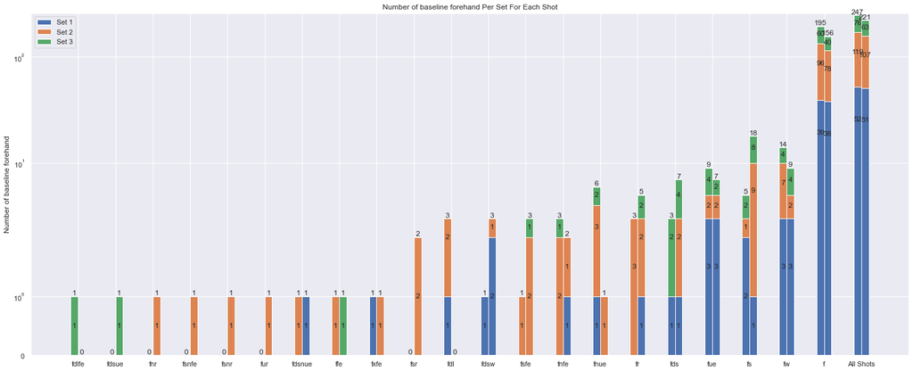

```python
df_baseline_forehand = baseline_shots_per_set('f')
plot_shots(df_baseline_forehand, 'baseline forehand')
plt.yscale('symlog')
df_baseline_forehand
```

## A count of baseline backhands by each player

*Same as forehands but shots with b and excluding shots with v or o.*

| Player | action | set 1 | set 2 | set 3 | Total |
| --- | --- | --- | --- | --- | --- |
| Michaels | b | 35 | 57 | 42 | 134 |
|  | bdl | 1 | 1 | 0 | 2 |
|  | bdlfe | 0 | 2 | 0 | 2 |
|  | bds | 2 | 7 | 2 | 11 |
|  | bdsnue | 0 | 1 | 0 | 1 |
|  | bdsue | 0 | 0 | 1 | 1 |
|  | bdsw | 0 | 1 | 0 | 1 |
|  | bfe | 0 | 1 | 1 | 2 |
|  | bnr | 0 | 2 | 0 | 2 |
|  | bnue | 6 | 2 | 0 | 8 |
|  | br | 2 | 1 | 0 | 3 |
|  | bs | 6 | 15 | 11 | 32 |
|  | bsnr | 0 | 0 | 2 | 2 |
|  | bsnue | 0 | 1 | 0 | 1 |
|  | bsr | 0 | 1 | 1 | 2 |
|  | bue | 1 | 2 | 1 | 4 |
|  | bur | 1 | 1 | 0 | 2 |
|  | bw | 1 | 0 | 2 | 3 |
|  | All Shots | 55 | 95 | 63 | 213 |
| Harrison | b | 24 | 47 | 29 | 100 |
|  | bdl | 0 | 5 | 2 | 7 |
|  | bds | 1 | 1 | 4 | 6 |
|  | bfe | 0 | 0 | 1 | 1 |
|  | bnfe | 0 | 1 | 0 | 1 |
|  | bnr | 0 | 1 | 0 | 1 |
|  | bnue | 2 | 1 | 4 | 7 |
|  | br | 1 | 0 | 1 | 2 |
|  | bs | 19 | 48 | 31 | 98 |
|  | bsfe | 0 | 0 | 1 | 1 |
|  | bsnue | 0 | 1 | 0 | 1 |
|  | bsr | 1 | 1 | 0 | 2 |
|  | bsue | 1 | 0 | 1 | 2 |
|  | bue | 1 | 5 | 3 | 9 |
|  | bur | 0 | 0 | 1 | 1 |
|  | bw | 3 | 2 | 3 | 8 |
|  | All Shots | 53 | 113 | 81 | 247 |

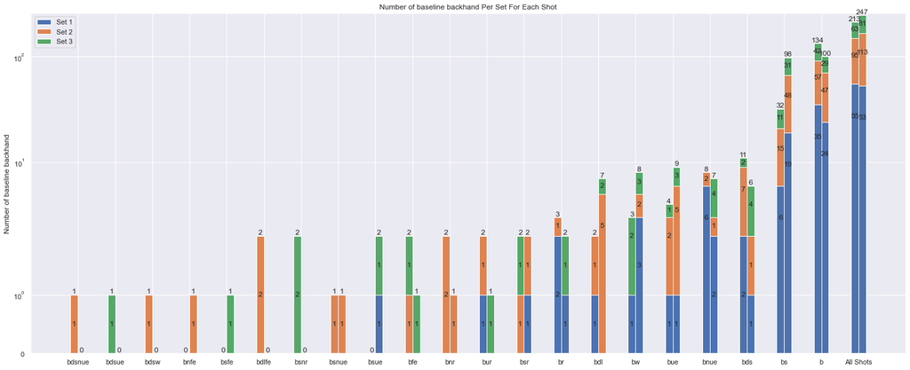

```python
df_baseline_backhand = baseline_shots_per_set('b')
plot_shots(df_baseline_backhand, 'baseline backhand')
plt.yscale('symlog')
df_baseline_backhand
```

## Average rally length

*The total number of actions by each player once a point has started with a serve in play. Ex. if a player hits a first serve and second serve then only the second serve that went in counts as the rally shot. Typically actions that are errors are also not counted but for now I'd like to try it with all shots that occur after a serve has gone in. I'd like this presented with just the average number (ex. 5.2).*

### Average Rally Length in the match

```python
not_counted_rallyshots = ['FSF','FSN','FSL','SSF','SSN','SSL','FSA','SSA']
rallyshots_dict = {}
for df_set,set_num in [(df_1, 'Set 1'),(df_2, 'Set 2'),(df_3, 'Set 3')]:
    rallyshots_per_point = df_set.query('action not in @not_counted_rallyshots').groupby(['game', 'point_number'])['action'].count()
    avg_rallyshots = rallyshots_per_point.mean()
    rallyshots_dict[set_num] = [avg_rallyshots]

df_rallyshots_per_set = pd.DataFrame(rallyshots_dict, index=['Average Rally length'])
df_rallyshots_per_set = df_rallyshots_per_set.merge(df_rallyshots_per_set.mean(axis=1).rename('Average'), how='outer', left_index=True, right_index=True)
```

|  | Set 1 | Set 2 | Set 3 | Average |
| --- | --- | --- | --- | --- |
| Average Rally length | 6.095238 | 6.909091 | 6.518519 | 6.507616 |

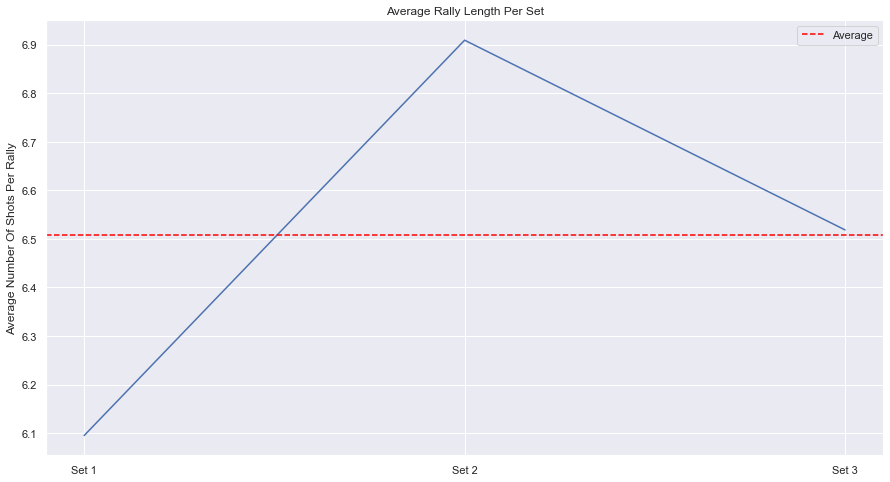

```python
plt.figure(figsize=(15,8))
plt.plot(df_rallyshots_per_set.loc['Average Rally length'][:3])
plt.axhline(df_rallyshots_per_set['Average'].loc['Average Rally length'], linestyle='--', label='Average', color='red')
plt.title('Average Rally length per set'.title())
plt.ylabel('Average number of shots per rally'.title())
plt.legend();

df_rallyshots_per_set
```

### Average Rally Length when each player is serving

```python
avg_rallylength_serving = df.query('action not in @not_counted_rallyshots').groupby(['serving','set','game','point_number'])['action'].count()
michaels_rallyshots_dict = {}
harrison_rallyshots_dict = {}
for df_set,set_num in [(df_1, 'Set 1'),(df_2, 'Set 2'),(df_3, 'Set 3')]:
    avg_rallyshots_list = []
    for player in ['Michaels','Harrison']:
        rallyshots_per_point = df_set.query('action not in @not_counted_rallyshots').groupby(['serving', 'game', 'point_number'])['action'].count()
        avg_rallyshots = rallyshots_per_point.loc[player].mean()
        avg_rallyshots_list.append(avg_rallyshots)
    rallyshots_dict[set_num] = avg_rallyshots_list

df_rallyshots_per_set = pd.DataFrame(rallyshots_dict, index=['Michaels Serving', 'Harrison Serving'])
df_rallyshots_per_set = df_rallyshots_per_set.merge(df_rallyshots_per_set.mean(axis=1).rename('Average'), how='outer', left_index=True, right_index=True)
```

|  | Set 1 | Set 2 | Set 3 | Average |
| --- | --- | --- | --- | --- |
| Michaels Serving | 6.300000 | 6.666667 | 5.653846 | 6.206838 |
| Harrison Serving | 5.909091 | 7.250000 | 7.321429 | 6.826840 |

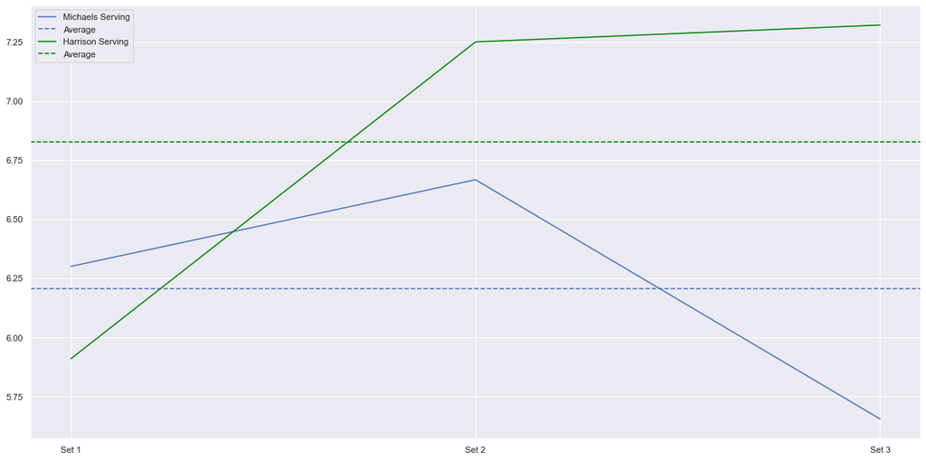

```python
plt.figure(figsize=(20,10))
plt.plot(df_rallyshots_per_set.loc['Michaels Serving'][:3], label='Michaels Serving')
plt.axhline(df_rallyshots_per_set['Average'].loc['Michaels Serving'], linestyle='--', label='Average')
plt.plot(df_rallyshots_per_set.loc['Harrison Serving'][:3], label='Harrison Serving', color='green')
plt.axhline(df_rallyshots_per_set['Average'].loc['Harrison Serving'], linestyle='--', label='Average', color='green')
plt.legend();

df_rallyshots_per_set
```

## Rally length 2-4, 5-7, 8-10, 11+

*This is a breakdown of the number of points in the match that are played within each category of total shots by the players. For example, 1-3 would include points with an ace all the way through to points with a serve, return, and either a winner or error by the server. 4-6 would be rallies with a serve that went in and at least 3 shots by the players up to 5 shots. I would like these expressed as fractions and percentages. For example, 30/100 rallies were 1-4, 20/100 were 5-8, etc. (30% and 20%).*

### Rally length in the match

```python
rally_length = df.query('action not in @not_counted_rallyshots').groupby(['set','game','point_number'])['action'].count().values
point_winner = df.query('action not in @not_counted_rallyshots').groupby(['set','game','point_number'])['point_winner'].unique().values
set_num = df.query('action not in @not_counted_rallyshots').groupby(['set','game','point_number'])['set'].unique().values
serving = df.query('action not in @not_counted_rallyshots').groupby(['set','game','point_number'])['serving'].unique().values
df_rallylength_category = pd.DataFrame({'Rally Length':rally_length, 'Serving':serving, 'Point Winner':point_winner, 'Set':set_num})
df_rallylength_category['Point Winner'] = df_rallylength_category['Point Winner'].apply(lambda x: x[0])
df_rallylength_category['Set'] = df_rallylength_category['Set'].apply(lambda x: x[0])
df_rallylength_category['Serving'] = df_rallylength_category['Serving'].apply(lambda x: x[0])
df_rallylength_category = df_rallylength_category.merge(pd.cut(df_rallylength_category['Rally Length'], [1,4,7,10,100], labels=['2-4','5-7','8-10','11+']).rename('Category'), how='outer', left_index=True, right_index=True)
rallies_number = df_rallylength_category['Category'].value_counts()
total_rallies = rallies_number.sum()
percentage_rallycategories = (rallies_number / total_rallies)*100
fraction = rallies_number.apply(lambda x: str(x)+'/'+str(total_rallies))
df_fraction = pd.DataFrame(fraction.rename('Fraction'))
df_percentage_rallycategories = pd.DataFrame(percentage_rallycategories.rename('Percentage'))
df_percentage_rallycategories = df_fraction.merge(df_percentage_rallycategories, how='outer', left_index=True, right_index=True)
```

|  | Fraction | Percentage |
| --- | --- | --- |
| 2-4 | 72/173 | 41.618497 |
| 5-7 | 42/173 | 24.277457 |
| 11+ | 32/173 | 18.497110 |
| 8-10 | 27/173 | 15.606936 |

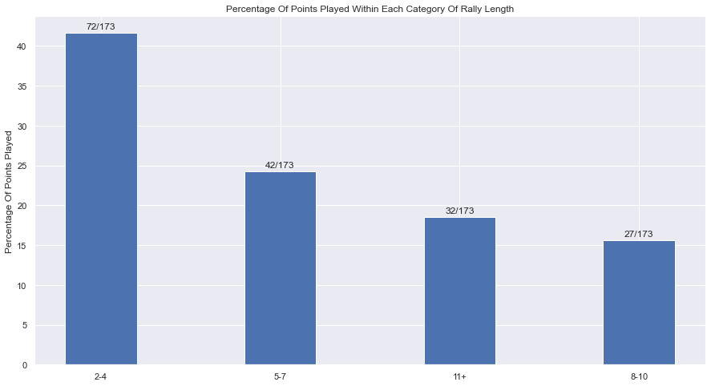

```python
plt.figure(figsize=(15,8))
plt.bar(np.arange(4), df_percentage_rallycategories['Percentage'], 0.4, tick_label=df_percentage_rallycategories.index)
for x, y in enumerate(df_percentage_rallycategories['Percentage']):
    plt.text(x, y+0.5, df_percentage_rallycategories['Fraction'][x], ha='center')
plt.ylabel('Percentage of points played'.title())
plt.title('Percentage of points played within each category of rally length'.title())

df_percentage_rallycategories
```

### Rally length per set

```python
rally_category_dict = {}
for set_number, df_set in enumerate([df_1,df_2,df_3]):
    rally_length = df_set.query('action not in @not_counted_rallyshots').groupby(['game','point_number'])['action'].count().values
    point_winner = df_set.query('action not in @not_counted_rallyshots').groupby(['game','point_number'])['point_winner'].unique().values
    df_rallylength_category_per_set = pd.DataFrame({'Rally Length':rally_length, 'Point Winner':point_winner})
    df_rallylength_category_per_set['Point Winner'] = df_rallylength_category_per_set['Point Winner'].apply(lambda x: x[0])
    df_rallylength_category_per_set = df_rallylength_category_per_set.merge(pd.cut(df_rallylength_category_per_set['Rally Length'], [1,4,7,10,100], labels=['2-4','5-7','8-10','11+']).rename('Category'), how='outer', left_index=True, right_index=True)
    rallies_number = df_rallylength_category_per_set['Category'].value_counts()
    total_rallies = rallies_number.sum()
    percentage = (rallies_number / total_rallies)*100
    fraction = rallies_number.apply(lambda x: str(x)+'/'+str(total_rallies))
    rally_category_dict[set_number+1] = [fraction['2-4'], percentage['2-4'], fraction['5-7'], percentage['5-7'], fraction['8-10'], percentage['8-10'], fraction['11+'], percentage['11+']]

df_rally_category_per_set = pd.DataFrame(rally_category_dict,
             index=pd.MultiIndex.from_tuples([('2-4','Fraction'),('2-4','Percentage'),('5-7','Fraction'),('5-7','Percentage'),('8-10','Fraction'),('8-10','Percentage'),('11+','Fraction'),('11+','Percentage')],
             name=['Category','Form']))
```

| Category | Form | 1 | 2 | 3 |
| --- | --- | --- | --- | --- |
| 2-4 | Fraction | 20/42 | 35/77 | 17/54 |
|  | Percentage | 47.619048 | 45.454545 | 31.481481 |
| 5-7 | Fraction | 10/42 | 11/77 | 21/54 |
|  | Percentage | 23.809524 | 14.285714 | 38.888889 |
| 8-10 | Fraction | 5/42 | 15/77 | 7/54 |
|  | Percentage | 11.904762 | 19.480519 | 12.962963 |
| 11+ | Fraction | 7/42 | 16/77 | 9/54 |
|  | Percentage | 16.666667 | 20.779221 | 16.666667 |

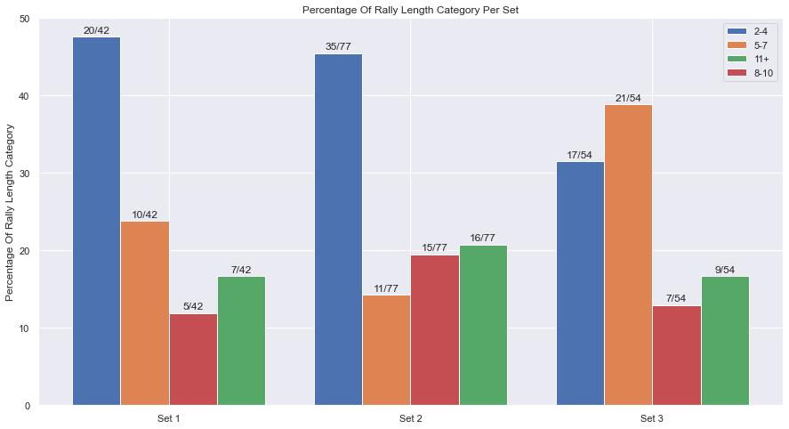

```python
plt.figure(figsize=(15,8))
plt.bar(np.arange(3)-0.4, df_rally_category_per_set.loc['2-4'].loc['Percentage'], 0.2, align='edge', tick_label=['Set 1','Set 2','Set 3'], label='2-4')
plt.bar(np.arange(3)-0.2, df_rally_category_per_set.loc['5-7'].loc['Percentage'], 0.2, align='edge', tick_label=['Set 1','Set 2','Set 3'], label='5-7')
plt.bar(np.arange(3)+0.2, df_rally_category_per_set.loc['11+'].loc['Percentage'], 0.2, align='edge', tick_label=['Set 1','Set 2','Set 3'], label='11+')
plt.bar(np.arange(3), df_rally_category_per_set.loc['8-10'].loc['Percentage'], 0.2, align='edge', tick_label=['Set 1','Set 2','Set 3'], label='8-10')

for x, y in enumerate(df_rally_category_per_set.loc['2-4'].loc['Percentage']):
    plt.text(x-0.3, y+0.5, df_rally_category_per_set.loc['2-4'].loc['Fraction'].iloc[x], ha='center')
for x, y in enumerate(df_rally_category_per_set.loc['5-7'].loc['Percentage']):
    plt.text(x-0.1, y+0.5, df_rally_category_per_set.loc['5-7'].loc['Fraction'].iloc[x], ha='center')
for x, y in enumerate(df_rally_category_per_set.loc['8-10'].loc['Percentage']):
    plt.text(x+0.1, y+0.5, df_rally_category_per_set.loc['8-10'].loc['Fraction'].iloc[x], ha='center')
for x, y in enumerate(df_rally_category_per_set.loc['11+'].loc['Percentage']):
    plt.text(x+0.3, y+0.5, df_rally_category_per_set.loc['11+'].loc['Fraction'].iloc[x], ha='center')

plt.ylabel('Percentage of rally length category'.title())
plt.title('Percentage of rally length category per set'.title())
plt.legend();

df_rally_category_per_set
```

### Rally Length per player who is serving

```python
rallylength_category_serving = pd.DataFrame(df_rallylength_category.groupby('Serving')['Category'].value_counts(normalize=True)*100)
rallylength_category_serving = rallylength_category_serving.loc['Michaels'].T.append(rallylength_category_serving.loc['Harrison'].T).set_axis(['Michaels','Harrison'],axis=0)
```

|  | 2-4 | 5-7 | 8-10 | 11+ |
| --- | --- | --- | --- | --- |
| Michaels | 43.956044 | 20.879121 | 19.78022 | 15.384615 |
| Harrison | 39.024390 | 28.048780 | 10.97561 | 21.951220 |

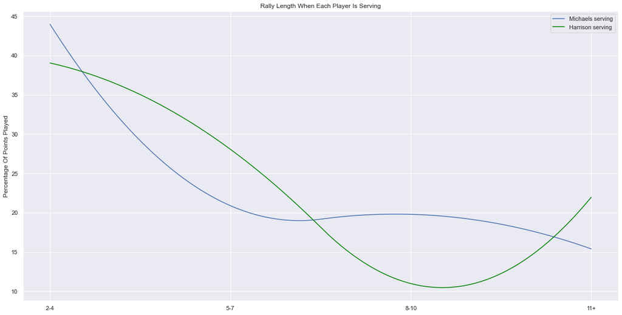

```python
plt.figure(figsize=(20,10))

x=['2-4','5-7','8-10','11+']
X_Y_Spline = make_interp_spline(np.arange(4), rallylength_category_serving.loc['Michaels'], 2)
X_ = np.linspace(np.arange(4).min(), np.arange(4).max(), 500)
Y_ = X_Y_Spline(X_)
plt.plot(X_, Y_, label='Michaels serving')

X_Y_Spline = make_interp_spline(np.arange(4), rallylength_category_serving.loc['Harrison'], 2)
X_ = np.linspace(np.arange(4).min(), np.arange(4).max(), 500)
Y_ = X_Y_Spline(X_)
plt.plot(X_, Y_, label='Harrison serving', color='green')

plt.xticks(np.arange(4),x)
plt.ylabel('Percentage of points played'.title())
plt.title('Rally length when each player is serving'.title())
plt.legend();

rallylength_category_serving
```

## Rally length success rate

_This would show how successful each player was at each rally length. Found by points won at each rally length / total points at that rally length. For example, Player_1 won 30/40 points (75%) at 1-3. Player*2 won 10/40 points (25%), etc.*

### Rally length success rate in the whole match

```python
rallylength_win_rate = df_rallylength_category.groupby('Category')['Point Winner'].value_counts()

michael_fraction_1 = str(rallylength_win_rate['2-4']['Michaels'])+'/'+str(rallylength_win_rate['2-4'].sum())
harrison_fraction_1 = str(rallylength_win_rate['2-4']['Harrison'])+'/'+str(rallylength_win_rate['2-4'].sum())
michael_fraction_4 = str(rallylength_win_rate['5-7']['Michaels'])+'/'+str(rallylength_win_rate['5-7'].sum())
harrison_fraction_4 = str(rallylength_win_rate['5-7']['Harrison'])+'/'+str(rallylength_win_rate['5-7'].sum())
michael_fraction_7 = str(rallylength_win_rate['8-10']['Michaels'])+'/'+str(rallylength_win_rate['8-10'].sum())
harrison_fraction_7 = str(rallylength_win_rate['8-10']['Harrison'])+'/'+str(rallylength_win_rate['8-10'].sum())
michael_fraction_10 = str(rallylength_win_rate['11+']['Michaels'])+'/'+str(rallylength_win_rate['11+'].sum())
harrison_fraction_10 = str(rallylength_win_rate['11+']['Harrison'])+'/'+str(rallylength_win_rate['11+'].sum())

for category in ['2-4','5-7','8-10','11+']:
    rallylength_win_rate[category] = ((rallylength_win_rate[category] / rallylength_win_rate[category].sum())*100).values

df_rallylength_win_rate = pd.DataFrame({'2-4':[michael_fraction_1,rallylength_win_rate['2-4']['Michaels'],harrison_fraction_1,rallylength_win_rate['2-4']['Harrison']],
                          '5-7':[michael_fraction_4,rallylength_win_rate['5-7']['Michaels'],harrison_fraction_4,rallylength_win_rate['5-7']['Harrison']],
                          '8-10':[michael_fraction_7,rallylength_win_rate['8-10']['Michaels'],harrison_fraction_7,rallylength_win_rate['8-10']['Harrison']],
                          '11+':[michael_fraction_10,rallylength_win_rate['11+']['Michaels'],harrison_fraction_10,rallylength_win_rate['11+']['Harrison']],},
                          index=pd.MultiIndex.from_tuples([('Michaels','Fraction'),('Michaels','Percentage'),('Harrison','Fraction'),('Harrison','Percentage')],
                          name=['Player','Form']))
```

| Player | Form | 2-4 | 5-7 | 8-10 | 11+ |
| --- | --- | --- | --- | --- | --- |
| Michaels | Fraction | 41/72 | 18/42 | 16/27 | 14/32 |
|  | Percentage | 56.944444 | 42.857143 | 59.259259 | 43.75 |
| Harrison | Fraction | 31/72 | 24/42 | 11/27 | 18/32 |
|  | Percentage | 43.055556 | 57.142857 | 40.740741 | 56.25 |

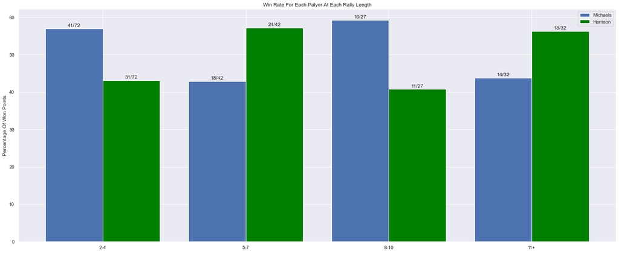

```python
plt.figure(figsize=(25,10))
plt.bar(np.arange(4)-0.4, df_rallylength_win_rate.loc['Michaels'].loc['Percentage'], 0.4, align='edge', tick_label=['2-4','5-7','8-10','11+'], label='Michaels')
plt.bar(np.arange(4), df_rallylength_win_rate.loc['Harrison'].loc['Percentage'], 0.4, align='edge', tick_label=['2-4','5-7','8-10','11+'], label='Harrison', color='green')

for x,y in enumerate(df_rallylength_win_rate.loc['Michaels'].loc['Percentage']):
    plt.text(x-0.2,y+0.5,df_rallylength_win_rate.loc['Michaels'].loc['Fraction'][x], ha='center')
for x,y in enumerate(df_rallylength_win_rate.loc['Harrison'].loc['Percentage']):
    plt.text(x+0.2,y+0.5,df_rallylength_win_rate.loc['Harrison'].loc['Fraction'][x], ha='center')

plt.ylabel('Percentage of won points'.title())
plt.title('Win rate for each palyer at each rally length'.title())
plt.legend();

df_rallylength_win_rate
```

### Rally length success rate per set

```python
michaels_winrate_dict = {}
harrison_winrate_dict = {}
michaels_fraction_dict = {}
harrison_fraction_dict = {}
for set_num in df_rallylength_category['Set'].unique():
    win_rate_groupby = df_rallylength_category.query('Set == @set_num').groupby('Category')['Point Winner'].value_counts()
    win_rate_groupby = pd.DataFrame(win_rate_groupby)
    for category in ['2-4','5-7','8-10','11+']:
        if set_num == 1 and category == '11+':
            win_rate_groupby = win_rate_groupby.append(pd.Series([0], index=['Point Winner'], name=('11+','Michaels')))
        michaels_fraction_dict[category] = str(win_rate_groupby.loc[category].loc['Michaels'].values[0])+'/'+str(win_rate_groupby.loc[category].sum().values[0])
        harrison_fraction_dict[category] = str(win_rate_groupby.loc[category].loc['Harrison'].values[0])+'/'+str(win_rate_groupby.loc[category].sum().values[0])
        for player in ['Michaels','Harrison']:
            win_rate_groupby.loc[category].loc[player] = ((win_rate_groupby.loc[category].loc[player]/win_rate_groupby.loc[category].sum())*100)
    michaels_winrate_dict[set_num] = [michaels_fraction_dict['2-4'], win_rate_groupby.loc['2-4'].loc['Michaels'].values[0],
                                      michaels_fraction_dict['5-7'], win_rate_groupby.loc['5-7'].loc['Michaels'].values[0],
                                      michaels_fraction_dict['8-10'], win_rate_groupby.loc['8-10'].loc['Michaels'].values[0],
                                      michaels_fraction_dict['11+'], win_rate_groupby.loc['11+'].loc['Michaels'].values[0]]
    harrison_winrate_dict[set_num] = [harrison_fraction_dict['2-4'], win_rate_groupby.loc['2-4'].loc['Harrison'].values[0],
                                      harrison_fraction_dict['5-7'], win_rate_groupby.loc['5-7'].loc['Harrison'].values[0],
                                      harrison_fraction_dict['8-10'], win_rate_groupby.loc['8-10'].loc['Harrison'].values[0],
                                      harrison_fraction_dict['11+'], win_rate_groupby.loc['11+'].loc['Harrison'].values[0]]

df_michaels_winrate = pd.DataFrame(michaels_winrate_dict, index=pd.MultiIndex.from_tuples([('2-4','Fraction'),('2-4','Percentage'),
                                                                                           ('5-7','Fraction'),('5-7','Percentage'),
                                                                                           ('8-10','Fraction'),('8-10','Percentage'),
                                                                                           ('11+','Fraction'),('11+','Percentage')], name=['Category','Form']))
df_harrison_winrate = pd.DataFrame(harrison_winrate_dict, index=pd.MultiIndex.from_tuples([('2-4','Fraction'),('2-4','Percentage'),
                                                                                           ('5-7','Fraction'),('5-7','Percentage'),
                                                                                           ('8-10','Fraction'),('8-10','Percentage'),
                                                                                           ('11+','Fraction'),('11+','Percentage')], name=['Category','Form']))
```

|  | Category | Form | 1 | 2 | 3 |
| --- | --- | --- | --- | --- | --- |
| Michaels | 2-4 | Fraction | 11/20 | 20/35 | 10/17 |
|  |  | Percentage | 11 | 20 | 10 |
|  | 5-7 | Fraction | 4/10 | 4/11 | 10/21 |
|  |  | Percentage | 40 | 4 | 10 |
|  | 8-10 | Fraction | 3/5 | 10/15 | 3/7 |
|  |  | Percentage | 60 | 10 | 3 |
|  | 11+ | Fraction | 0/7 | 6/16 | 8/9 |
|  |  | Percentage | 0 | 6 | 8 |
| Harrison | 2-4 | Fraction | 9/20 | 15/35 | 7/17 |
|  |  | Percentage | 45 | 15 | 7 |
|  | 5-7 | Fraction | 6/10 | 7/11 | 11/21 |
|  |  | Percentage | 6 | 7 | 11 |
|  | 8-10 | Fraction | 2/5 | 5/15 | 4/7 |
|  |  | Percentage | 2 | 5 | 4 |
|  | 11+ | Fraction | 7/7 | 10/16 | 1/9 |
|  |  | Percentage | 100 | 10 | 1 |

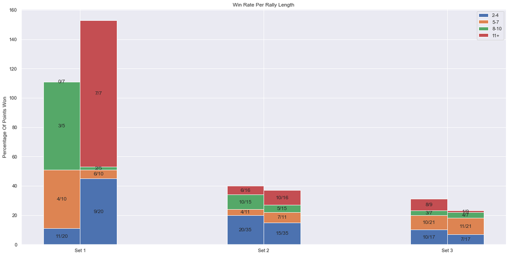

```python
plt.figure(figsize=(20,10))

p1_m = plt.bar(np.arange(3)-0.2, df_michaels_winrate.loc['2-4'].loc['Percentage'], 0.2, tick_label=['Set 1','Set 2','Set 3'], label='2-4', align='edge')
p2_m = plt.bar(np.arange(3)-0.2, df_michaels_winrate.loc['5-7'].loc['Percentage'], 0.2, p1_m.datavalues, tick_label=['Set 1','Set 2','Set 3'], label='5-7', align='edge')
p3_m = plt.bar(np.arange(3)-0.2, df_michaels_winrate.loc['8-10'].loc['Percentage'], 0.2, p1_m.datavalues+p2_m.datavalues, tick_label=['Set 1','Set 2','Set 3'], label='8-10', align='edge')
p4_m = plt.bar(np.arange(3)-0.2, df_michaels_winrate.loc['11+'].loc['Percentage'], 0.2, p1_m.datavalues+p2_m.datavalues+p3_m.datavalues, tick_label=['Set 1','Set 2','Set 3'], label='11+', align='edge')

plt.bar_label(p1_m, df_michaels_winrate.loc['2-4'].loc['Fraction'], label_type='center')
plt.bar_label(p2_m, df_michaels_winrate.loc['5-7'].loc['Fraction'], label_type='center')
plt.bar_label(p3_m, df_michaels_winrate.loc['8-10'].loc['Fraction'], label_type='center')
plt.bar_label(p4_m, df_michaels_winrate.loc['11+'].loc['Fraction'], label_type='center')

p1_h = plt.bar(np.arange(3), df_harrison_winrate.loc['2-4'].loc['Percentage'], 0.2, color=p1_m.patches[0].get_facecolor(), tick_label=['Set 1','Set 2','Set 3'], align='edge')
p2_h = plt.bar(np.arange(3), df_harrison_winrate.loc['5-7'].loc['Percentage'], 0.2, p1_h.datavalues, color=p2_m.patches[0].get_facecolor(), tick_label=['Set 1','Set 2','Set 3'], align='edge')
p3_h = plt.bar(np.arange(3), df_harrison_winrate.loc['8-10'].loc['Percentage'], 0.2, p1_h.datavalues+p2_h.datavalues, color=p3_m.patches[0].get_facecolor(), tick_label=['Set 1','Set 2','Set 3'], align='edge')
p4_h = plt.bar(np.arange(3), df_harrison_winrate.loc['11+'].loc['Percentage'], 0.2, p1_h.datavalues+p2_h.datavalues+p3_h.datavalues, color=p4_m.patches[0].get_facecolor(), tick_label=['Set 1','Set 2','Set 3'], align='edge')

plt.bar_label(p1_h, df_harrison_winrate.loc['2-4'].loc['Fraction'], label_type='center')
plt.bar_label(p2_h, df_harrison_winrate.loc['5-7'].loc['Fraction'], label_type='center')
plt.bar_label(p3_h, df_harrison_winrate.loc['8-10'].loc['Fraction'], label_type='center')
plt.bar_label(p4_h, df_harrison_winrate.loc['11+'].loc['Fraction'], label_type='center')

plt.ylabel('Percentage of points won'.title())
plt.title("Win rate per rally length".title())
plt.legend();

pd.concat([df_michaels_winrate, df_harrison_winrate], keys=['Michaels','Harrison'])
```

## Serve points won

_this is the total points won by each player when they are the serving player. I would like it expressed as the amount of points won/total points they served as well as in percentage form. Ex. Player*1 serves 70 points and wins 50 of them. This would be expressed as serve points won: 50/70 (71.4%). Note, FSL and SSL (the "L" stands for let) can be ignored here and in all of the rest of the statistics for the time being since lets are not technically points played since they are replayed. I would like to have total serve points won, first serve points won, and second serve points won.*

### Total serve points won

```python
def serve_points_won(df):
    """
    Returns a dataframe of the fraction and percentage of points won for each player for each set and for the whol match
    """
    winrate_dict = {}
    total_dict = {'Michaels':{'num':[],'total':[]},'Harrison':{'num':[],'total':[]}}
    for set_num in range(1,4):
        winrate_list = []
        for player in ['Michaels','Harrison']:
            winrate = df.loc[player].loc[set_num].value_counts()
            num = winrate[player]
            total = winrate.sum()
            fraction = str(num)+'/'+str(total)
            percentage = (num / total)*100
            winrate_list.append(fraction)
            winrate_list.append(percentage)
            total_dict[player]['num'].append(num)
            total_dict[player]['total'].append(total)
        winrate_dict['Set '+str(set_num)] = winrate_list

    total_list = []
    for player in ['Michaels','Harrison']:
        total_num = sum(total_dict[player]['num'])
        total_total = sum(total_dict[player]['total'])
        total_fraction = str(total_num)+'/'+str(total_total)
        total_percentage = (total_num/total_total)*100
        total_list.append(total_fraction)
        total_list.append(total_percentage)
    winrate_dict['Total'] = total_list

    return pd.DataFrame(winrate_dict, index=pd.MultiIndex.from_tuples([('Michaels', 'Fraction'),
                                                                       ('Michaels', 'Percentage'),
                                                                       ('Harrison', 'Fraction'),
                                                                       ('Harrison', 'Percentage')]))
```

```python
df_serving_winrate = df.groupby(['serving','set','game','point_number'])['point_winner'].unique().apply(lambda x: x[0])
df_serving_winrate = serve_points_won(df_serving_winrate)
```

|  |  | Set 1 | Set 2 | Set 3 | Total |
| --- | --- | --- | --- | --- | --- |
| Michaels | Fraction | 12/22 | 33/48 | 18/29 | 63/99 |
|  | Percentage | 54.545455 | 68.75 | 62.068966 | 63.636364 |
| Harrison | Fraction | 17/24 | 27/38 | 15/33 | 59/95 |
|  | Percentage | 70.833333 | 71.052632 | 45.454545 | 62.105263 |

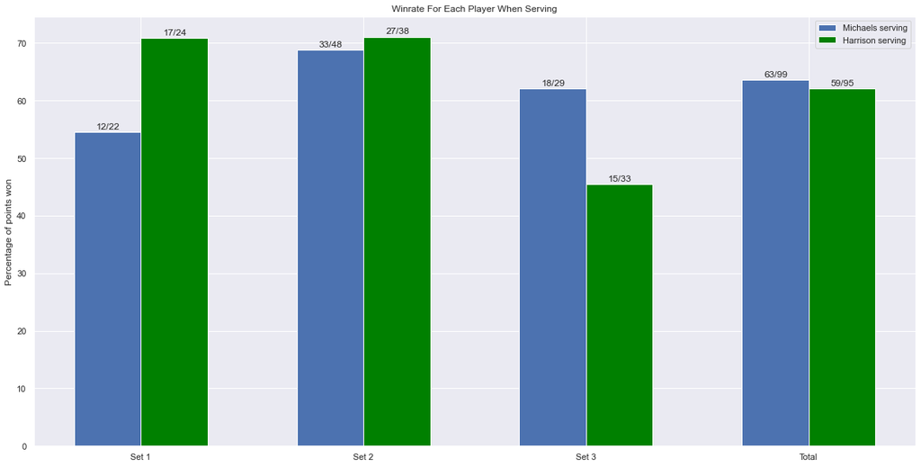

```python
plt.figure(figsize=(20,10))
plt.bar(np.arange(4)-0.3, df_serving_winrate.loc['Michaels'].loc['Percentage'], 0.3, align='edge', label='Michaels serving')
plt.bar(np.arange(4), df_serving_winrate.loc['Harrison'].loc['Percentage'], 0.3, align='edge', label='Harrison serving', color='green')

for x,y in enumerate(df_serving_winrate.loc['Michaels'].loc['Percentage']):
    plt.text(x-0.2, y+0.5, df_serving_winrate.loc['Michaels'].loc['Fraction'].iloc[x])
for x,y in enumerate(df_serving_winrate.loc['Harrison'].loc['Percentage']):
    plt.text(x+0.1, y+0.5, df_serving_winrate.loc['Harrison'].loc['Fraction'].iloc[x])

plt.xticks(np.arange(4), df_serving_winrate.columns)
plt.ylabel('Percentage of points won')
plt.title('Winrate for each player when serving'.title())
plt.legend();

df_serving_winrate
```

### First serve points won

```python
df_fs_winrate = pd.DataFrame(df.groupby(['serving','set','game','point_number','point_winner'])['action'].unique())
df_fs_winrate = df_fs_winrate[df_fs_winrate['action'].apply(lambda x: 'FS' in x or 'FSA' in x)].reset_index('point_winner').drop('action', axis=1).droplevel(['game','point_number'])
df_fs_winrate = serve_points_won(df_fs_winrate)
```

|  |  | Set 1 | Set 2 | Set 3 | Total |
| --- | --- | --- | --- | --- | --- |
| Michaels | Fraction | 6/12 | 22/31 | 15/22 | 43/65 |
|  | Percentage | 50.0 | 70.967742 | 68.181818 | 66.153846 |
| Harrison | Fraction | 12/17 | 20/23 | 12/20 | 44/60 |
|  | Percentage | 70.588235 | 86.956522 | 60.0 | 73.333333 |

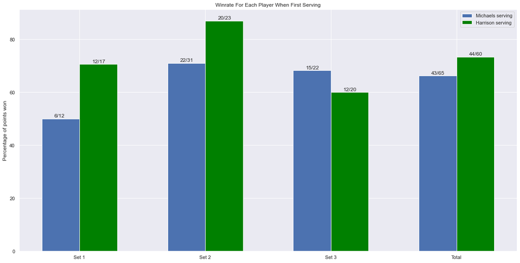

```python
plt.figure(figsize=(20,10))
plt.bar(np.arange(4)-0.3, df_fs_winrate.loc['Michaels'].loc['Percentage'], 0.3, align='edge', label='Michaels serving')
plt.bar(np.arange(4), df_fs_winrate.loc['Harrison'].loc['Percentage'], 0.3, align='edge', label='Harrison serving', color='green')

for x,y in enumerate(df_fs_winrate.loc['Michaels'].loc['Percentage']):
    plt.text(x-0.2, y+0.5, df_fs_winrate.loc['Michaels'].loc['Fraction'].iloc[x])
for x,y in enumerate(df_fs_winrate.loc['Harrison'].loc['Percentage']):
    plt.text(x+0.1, y+0.5, df_fs_winrate.loc['Harrison'].loc['Fraction'].iloc[x])

plt.xticks(np.arange(4), df_fs_winrate.columns)
plt.ylabel('Percentage of points won')
plt.title('Winrate for each player when first serving'.title())
plt.legend();

df_fs_winrate
```

### Second serve points won

```python
df_ss_winrate = pd.DataFrame(df.groupby(['serving','set','game','point_number','point_winner'])['action'].unique())
df_ss_winrate = df_ss_winrate[df_ss_winrate['action'].apply(lambda x: 'SS' in x or 'SSA' in x or 'SSN' in x or 'SSF' in x)].reset_index('point_winner').drop('action', axis=1).droplevel(['game','point_number'])

df_ss_winrate = serve_points_won(df_ss_winrate)
```

|  |  | Set 1 | Set 2 | Set 3 | Total |
| --- | --- | --- | --- | --- | --- |
| Michaels | Fraction | 6/10 | 11/17 | 3/7 | 20/34 |
|  | Percentage | 60.0 | 64.705882 | 42.857143 | 58.823529 |
| Harrison | Fraction | 5/7 | 7/15 | 3/13 | 15/35 |
|  | Percentage | 71.428571 | 46.666667 | 23.076923 | 42.857143 |

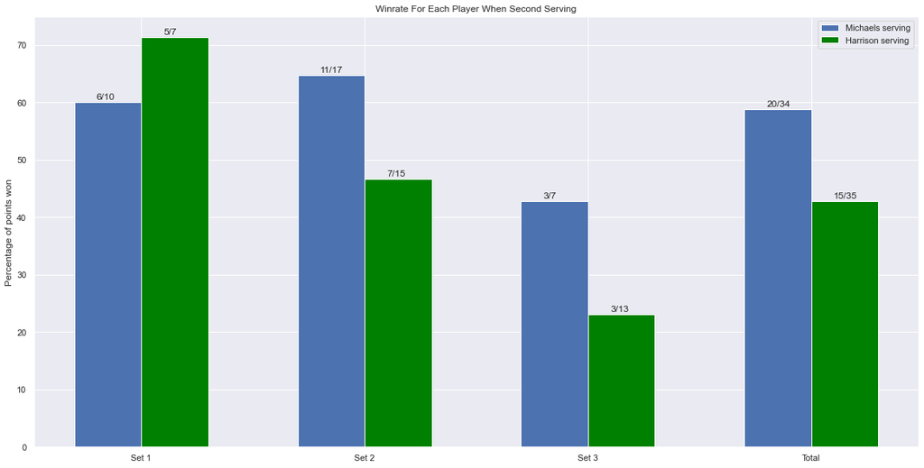

```python
plt.figure(figsize=(20,10))
plt.bar(np.arange(4)-0.3, df_ss_winrate.loc['Michaels'].loc['Percentage'], 0.3, align='edge', label='Michaels serving')
plt.bar(np.arange(4), df_ss_winrate.loc['Harrison'].loc['Percentage'], 0.3, align='edge', label='Harrison serving', color='green')

for x,y in enumerate(df_ss_winrate.loc['Michaels'].loc['Percentage']):
    plt.text(x-0.2, y+0.5, df_ss_winrate.loc['Michaels'].loc['Fraction'].iloc[x])
for x,y in enumerate(df_ss_winrate.loc['Harrison'].loc['Percentage']):
    plt.text(x+0.1, y+0.5, df_ss_winrate.loc['Harrison'].loc['Fraction'].iloc[x])

plt.xticks(np.arange(4), df_ss_winrate.columns)
plt.ylabel('Percentage of points won')
plt.title('Winrate for each player when second serving'.title())
plt.legend();

df_ss_winrate
```

## Aces

*These are the serve actions FSA (first serve ace) and SSA (second serve ace). I would like the actual number here for total aces, first serve aces, and second serve aces. It would also be great to have aces per first serve. This would just be the percentage of aces out of all first serves (lets in the form of FSL can again be ignored as serves here).*

### First Serve Aces

```python
df_fa = pd.DataFrame(df.groupby(['serving','set','game','point_number','point_winner'])['action'].unique())
df_fa = df_fa[df_fa['action'].apply(lambda x: 'FS' in x or 'FSA' in x)].reset_index('point_winner').droplevel(['game','point_number'])

fa_dict = {}
total_dict = {'Michaels':{'num':[],'total':[]},'Harrison':{'num':[],'total':[]}}
for set_num in range(1,4):
    fa_list = []
    for player in ['Michaels','Harrison']:
        fa_num = df_fa.loc[player].loc[set_num][df_fa.loc[player].loc[set_num]['action'].apply(lambda x: 'FSA' in x)]['point_winner'].count()
        fs = df_fa.loc[player].loc[set_num]['point_winner']
        fa_fraction = str(fa_num)+'/'+str(fs.count())
        fa_percentage = (fa_num / fs.count())*100
        fa_list.append(fa_fraction)
        fa_list.append(fa_percentage)
        total_dict[player]['num'].append(fa_num)
        total_dict[player]['total'].append(fs.count())
    fa_dict['Set '+str(set_num)] = fa_list

total_list = []
for player in ['Michaels','Harrison']:
    total_num = sum(total_dict[player]['num'])
    total_total = sum(total_dict[player]['total'])
    total_fraction = str(total_num)+'/'+str(total_total)
    total_percentage = (total_num/total_total)*100
    total_list.append(total_fraction)
    total_list.append(total_percentage)
fa_dict['Total'] = total_list

df_fa = pd.DataFrame(fa_dict, pd.MultiIndex.from_tuples([('Michaels','Fraction'),
                                                         ('Michaels','Percentage'),
                                                         ('Harrison','Fraction'),
                                                         ('Harrison','Percentage')]))
```

|  |  | Set 1 | Set 2 | Set 3 | Total |
| --- | --- | --- | --- | --- | --- |
| Michaels | Fraction | 1/12 | 2/31 | 3/22 | 6/65 |
|  | Percentage | 8.333333 | 6.451613 | 13.636364 | 9.230769 |
| Harrison | Fraction | 2/17 | 4/23 | 3/20 | 9/60 |
|  | Percentage | 11.764706 | 17.391304 | 15.0 | 15.0 |

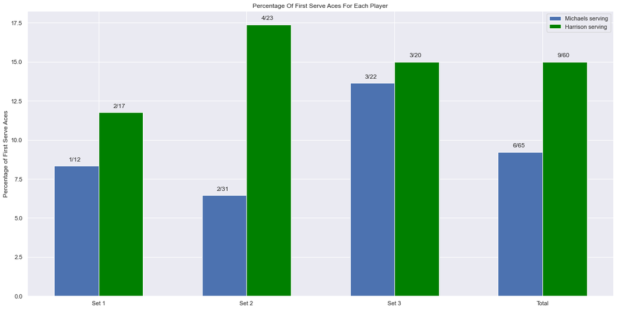

```python
plt.figure(figsize=(20,10))
plt.bar(np.arange(4)-0.3, df_fa.loc['Michaels'].loc['Percentage'], 0.3, align='edge', label='Michaels serving')
plt.bar(np.arange(4), df_fa.loc['Harrison'].loc['Percentage'], 0.3, align='edge', label='Harrison serving', color='green')

for x,y in enumerate(df_fa.loc['Michaels'].loc['Percentage']):
    plt.text(x-0.2, y+0.3, df_fa.loc['Michaels'].loc['Fraction'].iloc[x])
for x,y in enumerate(df_fa.loc['Harrison'].loc['Percentage']):
    plt.text(x+0.1, y+0.3, df_fa.loc['Harrison'].loc['Fraction'].iloc[x])

plt.xticks(np.arange(4), df_fa.columns)
plt.ylabel('Percentage of First Serve Aces')
plt.title('Percentage of First Serve Aces for each player'.title())
plt.legend();

df_fa
```

### Second Serve Aces

```python
'SSA' in df['action'].unique()
```

```
False
```

There is no Second Serve aces in the whole match

## Unreturnable Serves

*This can be found by looking for the returning player's actions with ur.*

```python
df_ur = shots_per_set('ur')
michaels_ur_serves = df_ur.loc['Harrison'].sum()
harrison_ur_serves = df_ur.loc['Michaels'].sum()
df_ur = pd.DataFrame({'Set 1':[michaels_ur_serves[0], harrison_ur_serves[0]],
                      'Set 2':[michaels_ur_serves[1], harrison_ur_serves[1]],
                      'Set 3':[michaels_ur_serves[2], harrison_ur_serves[2]],
                      'Total':[michaels_ur_serves[3], harrison_ur_serves[3]]},
                     index=['Michaels','Harrison'])
```

|  | Set 1 | Set 2 | Set 3 | Total |
| --- | --- | --- | --- | --- |
| Michaels | 0.0 | 3.0 | 3.0 | 6.0 |
| Harrison | 3.0 | 3.0 | 0.0 | 6.0 |

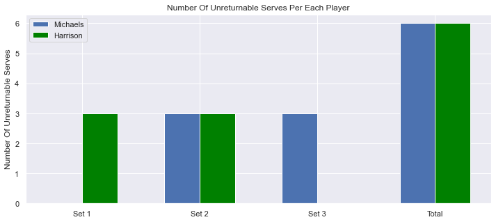

```python
plt.figure(figsize=(12,5))
plt.bar(np.arange(4)-0.3, df_ur.loc['Michaels'], 0.3, label='Michaels', align='edge')
plt.bar(np.arange(4), df_ur.loc['Harrison'], 0.3, label='Harrison', align='edge', color='green')
plt.title('Number of unreturnable serves per each player'.title())
plt.ylabel('Number of unreturnable serves'.title())
plt.xticks(np.arange(4), ['Set 1','Set 2','Set 3','Total'])
plt.legend()

df_ur
```

## Unreturned serves

*Serves that went in but were not returned in play by the returning player. Either the serving player hit an ace or the returning player hit the ball out. For this the action of the serving player needs to be FS, FSA, SS or SSA and the first action by the returning player needs to be a shot with an r (returnable serve that was missed), ur (unreturnable serve), ue (unforced error). Expressed as a fraction and percentage ex. 35/70 (50%). I would like to have a total number for this that combines first and second serves as well as for just first serves and just second serves.*

### Total Unreturned Serves

```python
df_points = pd.DataFrame(df.groupby(['serving','set','game','point_number','point_winner'])['action'].unique())
df_unreturned_serves = df_points[df_points['action'].apply(lambda x: 'FSA' in x or 'SSA' in x or 'r' in x[-1] or 'ur' in x[-1] or ('FS' in x and 'ue' in x[list(x).index('FS')+1]) or ('SS' in x and 'ue' in x[list(x).index('SS')+1]))]
df_unreturned_serves = df_unreturned_serves.reset_index('point_winner').droplevel(['game','point_number'])
df_serves_in = df_points[df_points['action'].apply(lambda x: 'FS' in x or 'SS' in x or 'FSA' in x or 'SSA' in x)]

fs_winrate_dict = {}
total_dict = {'Michaels':{'num':[],'total':[]},'Harrison':{'num':[],'total':[]}}
for set_num in range(1,4):
    fs_winrate_list = []
    for player in ['Michaels','Harrison']:
        fs_winrate = df_unreturned_serves.loc[player].loc[set_num]['action'].count()
        total = df_serves_in.loc[player].loc[set_num]['action'].count()
        fs_fraction = str(fs_winrate)+'/'+str(total)
        fs_percentage = (fs_winrate / total)*100
        fs_winrate_list.append(fs_fraction)
        fs_winrate_list.append(fs_percentage)
        total_dict[player]['num'].append(fs_winrate)
        total_dict[player]['total'].append(total)
    fs_winrate_dict['Set '+str(set_num)] = fs_winrate_list

total_list = []
for player in ['Michaels','Harrison']:
    total_num = sum(total_dict[player]['num'])
    total_total = sum(total_dict[player]['total'])
    total_fraction = str(total_num)+'/'+str(total_total)
    total_percentage = (total_num/total_total)*100
    total_list.append(total_fraction)
    total_list.append(total_percentage)
fs_winrate_dict['Total'] = total_list

df_unreturned_serves = pd.DataFrame(fs_winrate_dict, index=pd.MultiIndex.from_tuples([('Michaels','Fraction'),
                                                                               ('Michaels','Percentage'),
                                                                               ('Harrison','Fraction'),
                                                                               ('Harrison','Percentage')]))
```

|  |  | Set 1 | Set 2 | Set 3 | Total |
| --- | --- | --- | --- | --- | --- |
| Michaels | Fraction | 5/21 | 12/47 | 8/29 | 25/97 |
|  | Percentage | 23.809524 | 25.531915 | 27.586207 | 25.773196 |
| Harrison | Fraction | 6/24 | 13/36 | 6/31 | 25/91 |
|  | Percentage | 25.0 | 36.111111 | 19.354839 | 27.472527 |

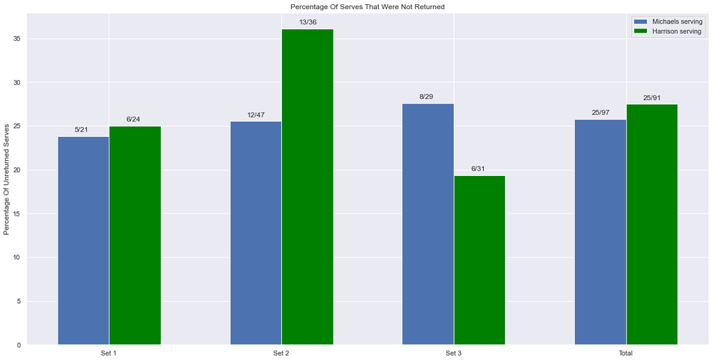

```python
plt.figure(figsize=(20,10))
plt.bar(np.arange(4)-0.3, df_unreturned_serves.loc['Michaels'].loc['Percentage'], 0.3, align='edge', label='Michaels serving')
plt.bar(np.arange(4), df_unreturned_serves.loc['Harrison'].loc['Percentage'], 0.3, align='edge', label='Harrison serving', color='green')

for x,y in enumerate(df_unreturned_serves.loc['Michaels'].loc['Percentage']):
    plt.text(x-0.2, y+0.5, df_unreturned_serves.loc['Michaels'].loc['Fraction'].iloc[x])
for x,y in enumerate(df_unreturned_serves.loc['Harrison'].loc['Percentage']):
    plt.text(x+0.1, y+0.5, df_unreturned_serves.loc['Harrison'].loc['Fraction'].iloc[x])

plt.xticks(np.arange(4), df_unreturned_serves.columns)
plt.ylabel('Percentage of unreturned serves'.title())
plt.title('Percentage of serves that were not returned'.title())
plt.legend();

df_unreturned_serves
```

### Unreturned First Serves

```python
df_fspoints = pd.DataFrame(df.groupby(['serving','set','game','point_number','point_winner'])['action'].unique())
df_unreturned_fsserves = df_fspoints[df_fspoints['action'].apply(lambda x: 'FSA' in x or ('FS' in x and ('r' in x[-1] or 'ur' in x[-1] or 'ue' in x[list(x).index('FS')+1])))]
df_unreturned_fsserves = df_unreturned_fsserves.reset_index('point_winner').droplevel(['game','point_number'])
df_serves_in = df_fspoints[df_fspoints['action'].apply(lambda x: 'FS' in x or 'FSA' in x)]

fs_winrate_dict = {}
total_dict = {'Michaels':{'num':[],'total':[]},'Harrison':{'num':[],'total':[]}}
for set_num in range(1,4):
    fs_winrate_list = []
    for player in ['Michaels','Harrison']:
        fs_winrate = df_unreturned_fsserves.loc[player].loc[set_num]['action'].count()
        total = df_serves_in.loc[player].loc[set_num]['action'].count()
        fs_fraction = str(fs_winrate)+'/'+str(total)
        fs_percentage = (fs_winrate / total)*100
        fs_winrate_list.append(fs_fraction)
        fs_winrate_list.append(fs_percentage)
        total_dict[player]['num'].append(fs_winrate)
        total_dict[player]['total'].append(total)
    fs_winrate_dict['Set '+str(set_num)] = fs_winrate_list

total_list = []
for player in ['Michaels','Harrison']:
    total_num = sum(total_dict[player]['num'])
    total_total = sum(total_dict[player]['total'])
    total_fraction = str(total_num)+'/'+str(total_total)
    total_percentage = (total_num/total_total)*100
    total_list.append(total_fraction)
    total_list.append(total_percentage)
fs_winrate_dict['Total'] = total_list

df_unreturned_fsserves = pd.DataFrame(fs_winrate_dict, index=pd.MultiIndex.from_tuples([('Michaels','Fraction'),
                                                                               ('Michaels','Percentage'),
                                                                               ('Harrison','Fraction'),
                                                                               ('Harrison','Percentage')]))
```

|  |  | Set 1 | Set 2 | Set 3 | Total |
| --- | --- | --- | --- | --- | --- |
| Michaels | Fraction | 4/12 | 11/31 | 6/22 | 21/65 |
|  | Percentage | 33.333333 | 35.483871 | 27.272727 | 32.307692 |
| Harrison | Fraction | 5/17 | 10/23 | 6/20 | 21/60 |
|  | Percentage | 29.411765 | 43.478261 | 30.0 | 35.0 |

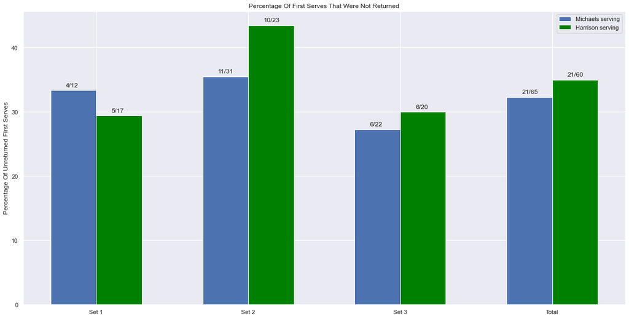

```python
plt.figure(figsize=(20,10))
plt.bar(np.arange(4)-0.3, df_unreturned_fsserves.loc['Michaels'].loc['Percentage'], 0.3, align='edge', label='Michaels serving')
plt.bar(np.arange(4), df_unreturned_fsserves.loc['Harrison'].loc['Percentage'], 0.3, align='edge', label='Harrison serving', color='green')

for x,y in enumerate(df_unreturned_fsserves.loc['Michaels'].loc['Percentage']):
    plt.text(x-0.2, y+0.5, df_unreturned_fsserves.loc['Michaels'].loc['Fraction'].iloc[x])
for x,y in enumerate(df_unreturned_fsserves.loc['Harrison'].loc['Percentage']):
    plt.text(x+0.1, y+0.5, df_unreturned_fsserves.loc['Harrison'].loc['Fraction'].iloc[x])

plt.xticks(np.arange(4), df_unreturned_fsserves.columns)
plt.ylabel('Percentage of unreturned first serves'.title())
plt.title('Percentage of first serves that were not returned'.title())
plt.legend();

df_unreturned_fsserves
```

### Unreturned Second Serves

```python
df_SSpoints = pd.DataFrame(df.groupby(['serving','set','game','point_number','point_winner'])['action'].unique())
df_unreturned_SSserves = df_SSpoints[df_SSpoints['action'].apply(lambda x: 'SSA' in x or ('SS' in x and ('r' in x[-1] or 'ur' in x[-1] or 'ue' in x[list(x).index('SS')+1])))]
df_unreturned_SSserves = df_unreturned_SSserves.reset_index('point_winner').droplevel(['game','point_number'])
df_serves_in = df_SSpoints[df_SSpoints['action'].apply(lambda x: 'SS' in x or 'SSA' in x)]

SS_winrate_dict = {}
total_dict = {'Michaels':{'num':[],'total':[]},'Harrison':{'num':[],'total':[]}}
for set_num in range(1,4):
    SS_winrate_list = []
    for player in ['Michaels','Harrison']:
        if set_num != 3 or player != 'Harrison':
            SS_winrate = df_unreturned_SSserves.reset_index().groupby(['serving','set'])['point_winner'].count().loc[player].loc[set_num]
        else:
            SS_winrate = 0
        total = df_serves_in.loc[player].loc[set_num]['action'].count()
        SS_fraction = str(SS_winrate)+'/'+str(total)
        SS_percentage = (SS_winrate / total)*100
        SS_winrate_list.append(SS_fraction)
        SS_winrate_list.append(SS_percentage)
        total_dict[player]['num'].append(SS_winrate)
        total_dict[player]['total'].append(total)
    SS_winrate_dict['Set '+str(set_num)] = SS_winrate_list

total_list = []
for player in ['Michaels','Harrison']:
    total_num = sum(total_dict[player]['num'])
    total_total = sum(total_dict[player]['total'])
    total_fraction = str(total_num)+'/'+str(total_total)
    total_percentage = (total_num/total_total)*100
    total_list.append(total_fraction)
    total_list.append(total_percentage)
SS_winrate_dict['Total'] = total_list

df_unreturned_SSserves = pd.DataFrame(SS_winrate_dict, index=pd.MultiIndex.from_tuples([('Michaels','Fraction'),
                                                                               ('Michaels','Percentage'),
                                                                               ('Harrison','Fraction'),
                                                                               ('Harrison','Percentage')]))
```

|  |  | Set 1 | Set 2 | Set 3 | Total |
| --- | --- | --- | --- | --- | --- |
| Michaels | Fraction | 1/9 | 1/16 | 2/7 | 4/32 |
|  | Percentage | 11.111111 | 6.25 | 28.571429 | 12.5 |
| Harrison | Fraction | 1/7 | 3/13 | 0/11 | 4/31 |
|  | Percentage | 14.285714 | 23.076923 | 0.0 | 12.903226 |

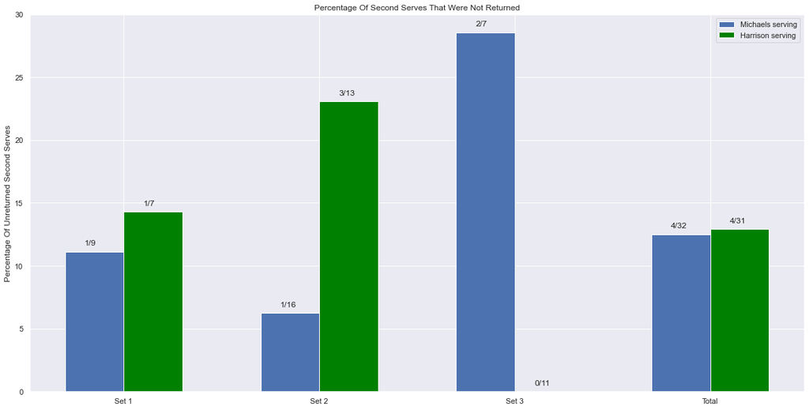

```python
plt.figure(figsize=(20,10))
plt.bar(np.arange(4)-0.3, df_unreturned_SSserves.loc['Michaels'].loc['Percentage'], 0.3, align='edge', label='Michaels serving')
plt.bar(np.arange(4), df_unreturned_SSserves.loc['Harrison'].loc['Percentage'], 0.3, align='edge', label='Harrison serving', color='green')

for x,y in enumerate(df_unreturned_SSserves.loc['Michaels'].loc['Percentage']):
    plt.text(x-0.2, y+0.5, df_unreturned_SSserves.loc['Michaels'].loc['Fraction'].iloc[x])
for x,y in enumerate(df_unreturned_SSserves.loc['Harrison'].loc['Percentage']):
    plt.text(x+0.1, y+0.5, df_unreturned_SSserves.loc['Harrison'].loc['Fraction'].iloc[x])

plt.xticks(np.arange(4), df_unreturned_SSserves.columns)
plt.ylabel('Percentage of unreturned second serves'.title())
plt.title('Percentage of second serves that were not returned'.title())
plt.legend();

df_unreturned_SSserves
```

## Serve Success Rate

### First Serve Success Rate

*The number of first serves that went in. FS and FSA represent serves that went in. FSF and FSN represent serves that were hit out.*

```python
df_fspoints = df.groupby(['serving','set','game','point_number'])['action'].unique()
df_fspoints = df_fspoints[df_fspoints.apply(lambda x: 'FS' in x or 'FSA' in x or 'FSF' in x or 'FSN' in x)].droplevel(['game','point_number'])
df_fs_in = df_fspoints[df_fspoints.apply(lambda x: 'FS' in x or 'FSA' in x)]

fs_accuracy_dict = {}
total_dict = {'Michaels':{'num':[],'total':[]},'Harrison':{'num':[],'total':[]}}
for set_num in range(1,4):
    fs_accuracy_list = []
    for player in ['Michaels','Harrison']:
        fs_accuracy = df_fs_in.loc[player].loc[set_num].count()
        total = df_fspoints.loc[player].loc[set_num].count()
        fs_fraction = str(fs_accuracy)+'/'+str(total)
        fs_percentage = (fs_accuracy / total)*100
        fs_accuracy_list.append(fs_fraction)
        fs_accuracy_list.append(fs_percentage)
        total_dict[player]['num'].append(fs_accuracy)
        total_dict[player]['total'].append(total)
    fs_accuracy_dict['Set '+str(set_num)] = fs_accuracy_list

total_list = []
for player in ['Michaels','Harrison']:
    total_num = sum(total_dict[player]['num'])
    total_total = sum(total_dict[player]['total'])
    total_fraction = str(total_num)+'/'+str(total_total)
    total_percentage = (total_num/total_total)*100
    total_list.append(total_fraction)
    total_list.append(total_percentage)
fs_accuracy_dict['Total'] = total_list

df_fs_in = pd.DataFrame(fs_accuracy_dict, index=pd.MultiIndex.from_tuples([('Michaels','Fraction'),
                                                                           ('Michaels','Percentage'),
                                                                           ('Harrison','Fraction'),
                                                                           ('Harrison','Percentage')]))
```

|  |  | Set 1 | Set 2 | Set 3 | Total |
| --- | --- | --- | --- | --- | --- |
| Michaels | Fraction | 12/22 | 31/48 | 22/29 | 65/99 |
|  | Percentage | 54.545455 | 64.583333 | 75.862069 | 65.656566 |
| Harrison | Fraction | 17/24 | 23/38 | 20/33 | 60/95 |
|  | Percentage | 70.833333 | 60.526316 | 60.606061 | 63.157895 |

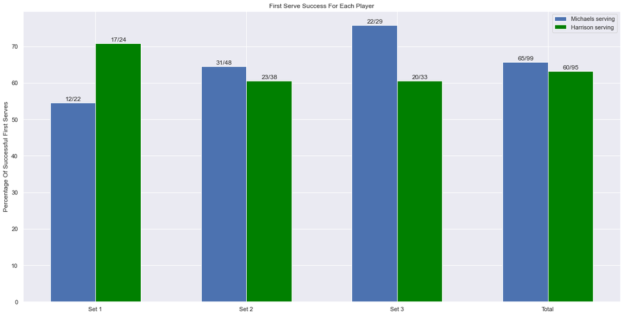

```python
plt.figure(figsize=(20,10))
plt.bar(np.arange(4)-0.3, df_fs_in.loc['Michaels'].loc['Percentage'], 0.3, align='edge', label='Michaels serving')
plt.bar(np.arange(4), df_fs_in.loc['Harrison'].loc['Percentage'], 0.3, align='edge', label='Harrison serving', color='green')

for x,y in enumerate(df_fs_in.loc['Michaels'].loc['Percentage']):
    plt.text(x-0.2, y+0.5, df_fs_in.loc['Michaels'].loc['Fraction'].iloc[x])
for x,y in enumerate(df_fs_in.loc['Harrison'].loc['Percentage']):
    plt.text(x+0.1, y+0.5, df_fs_in.loc['Harrison'].loc['Fraction'].iloc[x])

plt.xticks(np.arange(4), df_fs_in.columns)
plt.ylabel('Percentage of successful first serves'.title())
plt.title('first serve success for each player'.title())
plt.legend();

df_fs_in
```

### Second Serve Success Rate

*The same as for first serve percentage but counting second serves that have gone in (SS and SSA) and SSF and SSN for second serves that have gone out.*

```python
df_sspoints = df.groupby(['serving','set','game','point_number'])['action'].unique()
df_sspoints = df_sspoints[df_sspoints.apply(lambda x: 'SS' in x or 'SSA' in x or 'SSF' in x or 'SSN' in x)].droplevel(['game','point_number'])
df_ss_in = df_sspoints[df_sspoints.apply(lambda x: 'SS' in x or 'SSA' in x)]

fs_accuracy_dict = {}
total_dict = {'Michaels':{'num':[],'total':[]},'Harrison':{'num':[],'total':[]}}
for set_num in range(1,4):
    fs_accuracy_list = []
    for player in ['Michaels','Harrison']:
        fs_accuracy = df_ss_in.loc[player].loc[set_num].count()
        total = df_sspoints.loc[player].loc[set_num].count()
        fs_fraction = str(fs_accuracy)+'/'+str(total)
        fs_percentage = (fs_accuracy / total)*100
        fs_accuracy_list.append(fs_fraction)
        fs_accuracy_list.append(fs_percentage)
        total_dict[player]['num'].append(fs_accuracy)
        total_dict[player]['total'].append(total)
    fs_accuracy_dict['Set '+str(set_num)] = fs_accuracy_list

total_list = []
for player in ['Michaels','Harrison']:
    total_num = sum(total_dict[player]['num'])
    total_total = sum(total_dict[player]['total'])
    total_fraction = str(total_num)+'/'+str(total_total)
    total_percentage = (total_num/total_total)*100
    total_list.append(total_fraction)
    total_list.append(total_percentage)
fs_accuracy_dict['Total'] = total_list

df_ss_in = pd.DataFrame(fs_accuracy_dict, index=pd.MultiIndex.from_tuples([('Michaels','Fraction'),
                                                                           ('Michaels','Percentage'),
                                                                           ('Harrison','Fraction'),
                                                                           ('Harrison','Percentage')]))
```

|  |  | Set 1 | Set 2 | Set 3 | Total |
| --- | --- | --- | --- | --- | --- |
| Michaels | Fraction | 9/10 | 16/17 | 7/7 | 32/34 |
|  | Percentage | 90.0 | 94.117647 | 100.0 | 94.117647 |
| Harrison | Fraction | 7/7 | 13/15 | 11/13 | 31/35 |
|  | Percentage | 100.0 | 86.666667 | 84.615385 | 88.571429 |

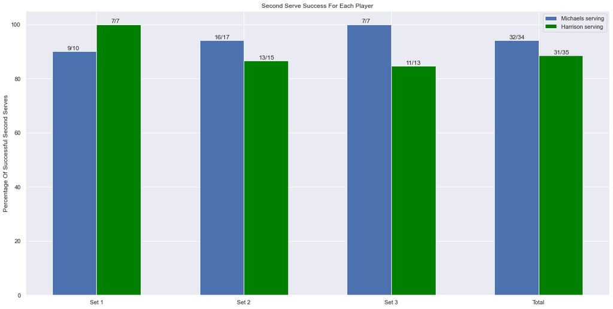

```python
plt.figure(figsize=(20,10))
plt.bar(np.arange(4)-0.3, df_ss_in.loc['Michaels'].loc['Percentage'], 0.3, align='edge', label='Michaels serving')
plt.bar(np.arange(4), df_ss_in.loc['Harrison'].loc['Percentage'], 0.3, align='edge', label='Harrison serving', color='green')

for x,y in enumerate(df_ss_in.loc['Michaels'].loc['Percentage']):
    plt.text(x-0.2, y+0.5, df_ss_in.loc['Michaels'].loc['Fraction'].iloc[x])
for x,y in enumerate(df_ss_in.loc['Harrison'].loc['Percentage']):
    plt.text(x+0.1, y+0.5, df_ss_in.loc['Harrison'].loc['Fraction'].iloc[x])

plt.xticks(np.arange(4), df_ss_in.columns)
plt.ylabel('Percentage of successful second serves'.title())
plt.title('second serve success for each player'.title())
plt.legend();

df_ss_in
```

### Double faults

*This is just a total count of the number of SSF plus SSN for the serving player. Double faults per second serve similar to aces per first serve would be also great.*

```python
df_sspoints = df.groupby(['serving','set','game','point_number'])['action'].unique()
df_sspoints = df_sspoints[df_sspoints.apply(lambda x: 'SS' in x or 'SSA' in x or 'SSF' in x or 'SSN' in x)]
df_double_faults = df_sspoints[df_sspoints.apply(lambda x: 'SSF' in x or 'SSN' in x)].droplevel(['game','point_number'])

double_faults_dict = {}
total_dict = {'Michaels':{'num':[],'total':[]},'Harrison':{'num':[],'total':[]}}
for set_num in range(1,4):
    double_faults_list = []
    for player in ['Michaels','Harrison']:
        try:
            double_faults = (df_double_faults.loc[player].index.get_level_values('set')==set_num).sum()
        except:
            double_faults = 0
        total = df_sspoints.loc[player].loc[set_num].count()
        fs_fraction = str(double_faults)+'/'+str(total)
        fs_percentage = (double_faults / total)*100
        double_faults_list.append(fs_fraction)
        double_faults_list.append(fs_percentage)
        total_dict[player]['num'].append(double_faults)
        total_dict[player]['total'].append(total)
    double_faults_dict['Set '+str(set_num)] = double_faults_list

total_list = []
for player in ['Michaels','Harrison']:
    total_num = sum(total_dict[player]['num'])
    total_total = sum(total_dict[player]['total'])
    total_fraction = str(total_num)+'/'+str(total_total)
    total_percentage = (total_num/total_total)*100
    total_list.append(total_fraction)
    total_list.append(total_percentage)
double_faults_dict['Total'] = total_list

df_double_faults = pd.DataFrame(double_faults_dict, index=pd.MultiIndex.from_tuples([('Michaels','Fraction'),
                                                                               ('Michaels','Percentage'),
                                                                               ('Harrison','Fraction'),
                                                                               ('Harrison','Percentage')]))
```

|  |  | Set 1 | Set 2 | Set 3 | Total |
| --- | --- | --- | --- | --- | --- |
| Michaels | Fraction | 1/10 | 1/17 | 0/7 | 2/34 |
|  | Percentage | 10.0 | 5.882353 | 0.0 | 5.882353 |
| Harrison | Fraction | 0/7 | 2/15 | 2/13 | 4/35 |
|  | Percentage | 0.0 | 13.333333 | 15.384615 | 11.428571 |

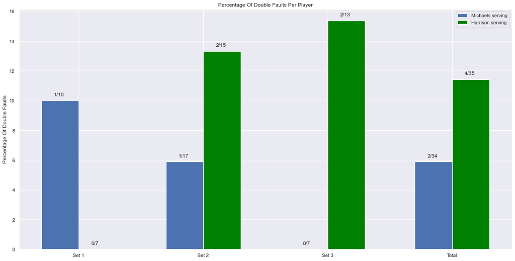

```python
plt.figure(figsize=(20,10))
plt.bar(np.arange(4)-0.3, df_double_faults.loc['Michaels'].loc['Percentage'], 0.3, align='edge', label='Michaels serving')
plt.bar(np.arange(4), df_double_faults.loc['Harrison'].loc['Percentage'], 0.3, align='edge', label='Harrison serving', color='green')

for x,y in enumerate(df_double_faults.loc['Michaels'].loc['Percentage']):
    plt.text(x-0.2, y+0.3, df_double_faults.loc['Michaels'].loc['Fraction'].iloc[x])
for x,y in enumerate(df_double_faults.loc['Harrison'].loc['Percentage']):
    plt.text(x+0.1, y+0.3, df_double_faults.loc['Harrison'].loc['Fraction'].iloc[x])

plt.xticks(np.arange(4), df_double_faults.columns)
plt.ylabel('Percentage of double faults'.title())
plt.title('Percentage of double faults per player'.title())
plt.legend();

df_double_faults
```

## Service games won

*like service points won but the total games won by each player when they are serving expressed as a fraction and percentage.*

```python
df_games = df.groupby(['serving','set','game','point_number'])['point_winner'].unique().apply(lambda x: x[0])

game_winner_list = []
for player in ['Harrison','Michaels']:
    for set_num in range(1,4):
        for game in df_games.loc[player].loc[set_num].index.get_level_values('game'):
            game_winner_list.append(list(df_games.loc[player].loc[set_num].loc[game])[-1])

df_games = pd.DataFrame(df_games).reset_index().merge(pd.Series(game_winner_list, name='game_winner'), how='outer', left_index=True, right_index=True)
df_games = df_games.groupby(['serving','set','game'])['game_winner'].unique().apply(lambda x: x[0])

games_won_dict = {}
total_dict = {'Michaels':{'num':[],'total':[]},'Harrison':{'num':[],'total':[]}}
for set_num in range(1,4):
    games_won_list = []
    for player in ['Michaels', 'Harrison']:
        games_won = df_games.loc[player].loc[set_num].value_counts()
        total = games_won.sum()
        games_fraction = str(games_won[player])+'/'+str(total)
        games_percentage= (games_won[player] / total)*100
        games_won_list.append(games_fraction)
        games_won_list.append(games_percentage)
        total_dict[player]['num'].append(games_won[player])
        total_dict[player]['total'].append(total)
    games_won_dict['Set '+str(set_num)] = games_won_list

total_list = []
for player in ['Michaels','Harrison']:
    total_num = sum(total_dict[player]['num'])
    total_total = sum(total_dict[player]['total'])
    total_fraction = str(total_num)+'/'+str(total_total)
    total_percentage = (total_num/total_total)*100
    total_list.append(total_fraction)
    total_list.append(total_percentage)
games_won_dict['Total'] = total_list

df_serving_games_won = pd.DataFrame(games_won_dict, index=pd.MultiIndex.from_tuples([('Michaels','Fraction'),
                                                                                     ('Michaels','Percentage'),
                                                                                     ('Harrison','Fraction'),
                                                                                     ('Harrison','Percentage')]))
```

|  |  | Set 1 | Set 2 | Set 3 | Total |
| --- | --- | --- | --- | --- | --- |
| Michaels | Fraction | 2/4 | 7/7 | 3/4 | 12/15 |
|  | Percentage | 50.0 | 100.0 | 75.0 | 80.0 |
| Harrison | Fraction | 4/4 | 6/7 | 2/5 | 12/16 |
|  | Percentage | 100.0 | 85.714286 | 40.0 | 75.0 |

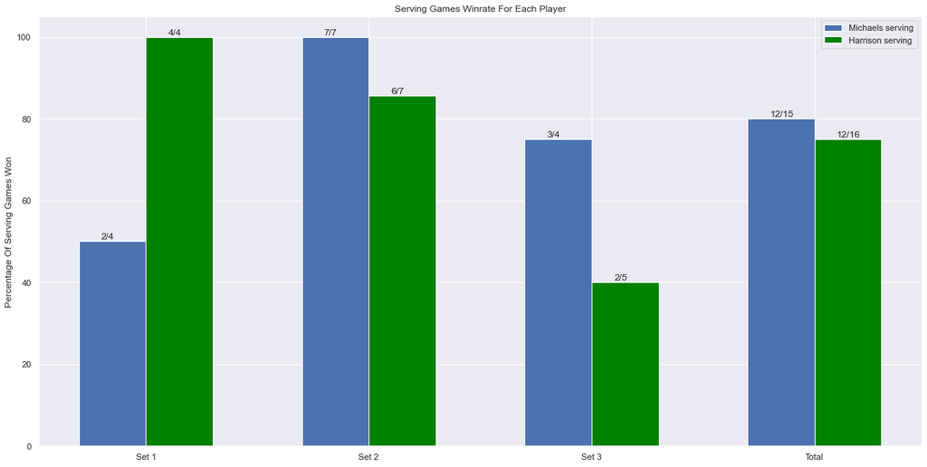

```python
plt.figure(figsize=(20,10))
plt.bar(np.arange(4)-0.3, df_serving_games_won.loc['Michaels'].loc['Percentage'], 0.3, align='edge', label='Michaels serving')
plt.bar(np.arange(4), df_serving_games_won.loc['Harrison'].loc['Percentage'], 0.3, align='edge', label='Harrison serving', color='green')

for x,y in enumerate(df_serving_games_won.loc['Michaels'].loc['Percentage']):
    plt.text(x-0.2, y+0.5, df_serving_games_won.loc['Michaels'].loc['Fraction'].iloc[x])
for x,y in enumerate(df_serving_games_won.loc['Harrison'].loc['Percentage']):
    plt.text(x+0.1, y+0.5, df_serving_games_won.loc['Harrison'].loc['Fraction'].iloc[x])

plt.xticks(np.arange(4), df_serving_games_won.columns)
plt.ylabel('Percentage of serving games won'.title())
plt.title('Serving games winrate for each player'.title())
plt.legend();

df_serving_games_won
```

## Net points won

*Net points are points with shots that contain a v or o. For this I'd like net points won/total net points as well as the percentage.*

```python
df_net_winrate = df[(df.action.str.contains("v")) + (df.action.str.contains('o'))].groupby(['player_with_action','set','game','point_number'])['point_winner'].unique().apply(lambda x: x[0])

net_winrate_dict = {}
total_dict = {'Michaels':{'num':[],'total':[]},'Harrison':{'num':[],'total':[]}}
for set_num in range(1,4):
    net_winrate_list = []
    for player in ['Michaels','Harrison']:
        try:
            player_net_winrate = df_net_winrate[player][set_num]
            num = player_net_winrate.value_counts()[player]
            total = player_net_winrate.count()
            percentage = (num/total)*100
        except:
            num, total, percentage = 0,0,0
        fraction = str(num)+'/'+str(total)
        net_winrate_list.append(fraction)
        net_winrate_list.append(percentage)
        total_dict[player]['num'].append(num)
        total_dict[player]['total'].append(total)
    net_winrate_dict['Set '+str(set_num)] = net_winrate_list

total_list = []
for player in ['Michaels','Harrison']:
    total_num = sum(total_dict[player]['num'])
    total_total = sum(total_dict[player]['total'])
    total_fraction = str(total_num)+'/'+str(total_total)
    total_percentage = (total_num/total_total)*100
    total_list.append(total_fraction)
    total_list.append(total_percentage)
net_winrate_dict['Total'] = total_list

index_list = []
for p in ['Michaels','Harrison']:
    for f in ['Fraction','Percentage']:
        index_list.append((p,f))
index = pd.MultiIndex.from_tuples(index_list)
df_net_winrate = pd.DataFrame(net_winrate_dict, index=index)
```

|  |  | Set 1 | Set 2 | Set 3 | Total |
| --- | --- | --- | --- | --- | --- |
| Michaels | Fraction | 0/0 | 7/10 | 5/8 | 12/18 |
|  | Percentage | 0 | 70.0 | 62.5 | 66.666667 |
| Harrison | Fraction | 2/3 | 7/8 | 1/6 | 10/17 |
|  | Percentage | 66.666667 | 87.5 | 16.666667 | 58.823529 |

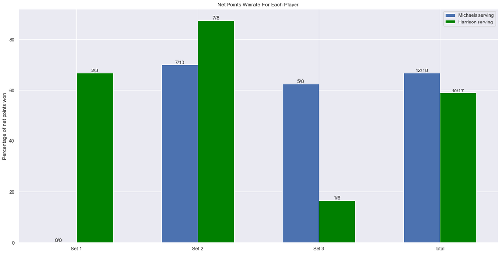

```python
plt.figure(figsize=(20,10))
p1 = plt.bar(np.arange(4)-0.3, df_net_winrate.loc['Michaels', 'Percentage'], 0.3, align='edge', label='Michaels serving')
p2 = plt.bar(np.arange(4), df_net_winrate.loc['Harrison', 'Percentage'], 0.3, align='edge', label='Harrison serving', color='green')

plt.bar_label(p1, df_net_winrate.loc['Michaels','Fraction'])
plt.bar_label(p2, df_net_winrate.loc['Harrison','Fraction'])

plt.xticks(np.arange(4), df_net_winrate.columns)
plt.ylabel('Percentage of net points won')
plt.title('Net points Winrate for each player'.title())
plt.legend();

df_net_winrate
```